# Environmental and local habitat variables as predictors of trophic interactions in subtidal rocky reefs along the SE Pacific coast

12-08-2024

## Clear the environment

```r
rm(list = ls())
```

## Load packages

*Before loading the packages install them using *install()**

```r
library(tidyverse)
library(summarytools)
library(dplyr)
library(readr)
library(vegan)
library(patchwork)
library(pander)
library(ggeffects)
library(performance)
library(knitr)
library(car)
library(corrplot)
library(MASS)
library(MuMIn)
library(geosphere)
library(mgcv)
```

```r
#If Issues installing packages
options("install.lock"=FALSE)
```

## **Part 1:** Importing and examining data

In this part the data frames were inspected in order to check the variable names and types. In some situations the data set was slightly modified for further manipulation of them.

### **1a)** Import data

```r
Environmental1 <- read.csv("Data/Environmental_variables.csv")
Metadata <- read.csv("Data/Metadata_lat2018-2019.csv")
Herbivory <- read.csv("Data/Herbivory_latitudinal2018-2019.csv")
Benthic <- read.csv("Data/Percent_cover.csv")
Phlorotannins <- read.csv("Data/Phlorotannins.csv")
Predation <- read.csv("Data/Predation_latitudinal2018-2019.csv")
Size <- read.csv("Data/Size_estimations.csv")
Transects <- read.csv("Data/Transect2018-2019.csv")
```

### **1b)** Inspect structure of data frames

1. Site metadata

```r
view(dfSummary(Metadata))

#Rename temperature variables to avoid confusion with replicate measures in Environmental data
Metadata <- rename(Metadata, Temperature_site = Temperature_C)
```

2. Environmental data

```r
view(dfSummary(Environmental1))

Environmental <- Environmental1 %>%
  rename(D_oxygen_percent = X., D_oxygen_mgL = D_oxygen) %>% #Rename oxygen percent variable
  dplyr::select(-Date,-Campaign,-Latitude) #Remove variables that are in Metadata
```

3. Benthic cover

```r
view(dfSummary(Benthic))
Benthic <- Benthic %>%
  dplyr::select(-Date) #Remove variables that are in Metadata
```

4. Herbivory

```r
view(dfSummary(Herbivory))
Herbivory <- Herbivory %>%
  dplyr::select(-Date,-Campaign,-Season) %>%# Remove variables that are in Metadata
  mutate(Consumed_proportion = (Initial_length_mm-Final_Length_mm)/Initial_length_mm)
```

It was necessary to create major categories for Bait

```r
Herbivory <- mutate(Herbivory, Bait2 = case_when(Bait == "Lessonia_spicata" ~ "Lessonia sp.",
                                                 Bait == "Lessonia_berteroana" ~ "Lessonia sp."))
```

5. Predation

```r
view(dfSummary(Predation))
Predation <- Predation %>%
  dplyr::select(-Date,-Campaign,-Season)  %>%# Remove variables that are in Metadata
mutate(Consumed_proportion = (Initial_Individuals-Remaining_individuals)/Initial_Individuals, Consumed_individuals = Initial_Individuals-Remaining_individuals) #Add Consumed_proportion column
```

Create major categories for Bait (Squidpops vs Crabs) and Assay time (2 hours and 24 hours)

```r
Predation <- mutate(Predation, Bait2 = case_when(Bait == "Squidpops" ~ "Squidpops",
                                                 Bait != "Squidpops" ~ "Crabs"), Assay_time2 = case_when(Assay_time == "24" ~ "24",
                                                 Bait != "24" ~ "2"))
```

6. Phlorotannins

```r
view(dfSummary(Phlorotannins))
Phlorotannins <- Phlorotannins %>%
  dplyr::select(-Date,-Latitude) # Remove variables that are in metadata
```

7. Size

```r
view(dfSummary(Size))
Size <- Size %>%
  dplyr::select(-Date,-Campaign) # Remove variables that are in Metadata
```

8. Transects

```r
view(dfSummary(Transects))
Transects <- Transects %>%
  dplyr::select(-Date,-Campaign) # Remove variables that are in Metadata
```

## **Part 2:** Manipulating datasets

In this section data sets are manipulated for analyses. New data sets with means and combined with metadata and consumption are created.

### **2a)** Environmental data

1. Join Environmental data with metadata

```r
Environmental_metadata <- Environmental %>%
    left_join(Metadata, by = "Site")
```

2. Join Environmental data with consumption
- First summarise environmental data per site

```r
Environmental_2 <- Environmental_metadata %>%
  group_by(Site, Latitude) %>%
  dplyr::select(-D_oxygen_percent, -Conductivity_Ms, -C_f, -C_i, -H_Visibility) #Keep only variables that will be used in the analysis

Environmental_2$Day_length <- daylength(Environmental_2$Latitude, Environmental_2$Date)


Environmental_sum_long <- Environmental_2 %>%
  dplyr::select(Site, Latitude, Temperature, D_oxygen_mgL, Salinity_ppt, V_Visibility, Day_length) %>%
  gather(Env_Variable, Value, Temperature:Day_length) %>%
  group_by(Site, Latitude, Env_Variable)%>%
  summarise(Mean_value = mean(Value, na.rm=T),n = n(), sd = sd(Value,na.rm=T), se = sd/sqrt(n))

Environmental_sum <- Environmental_sum_long %>%
  dplyr::select(Site, Env_Variable, Mean_value) %>%
pivot_wider(names_from = Env_Variable, values_from = Mean_value,
              values_fill = 0)
```

- Then, add environmental data to consumption
- Predation vs environmental data sets

```r
Predation_env <- Predation %>%
    left_join(Environmental_sum, by = "Site")
```

- Herbivory vs environmental data sets

```r
Herbivory_env <- Herbivory %>%
  left_join(Environmental_sum, by = "Site")
```

### *2b):* Benthic data

1. Join benthic data with metadata

```r
Benthic_metadata <- Benthic  %>%
    left_join(Metadata, by = "Site")

Benthic_metadata_wide <- Benthic_metadata %>%
  group_by(Site, Latitude, Type) %>%
  pivot_wider(names_from = Type, values_from = Coverage,
              values_fill = 0)
```

2. Calculate mean, sd, and se by group

```r
Benthic_mean <- Benthic_metadata %>%
  group_by(Site, Latitude, Type)%>%
  summarise(Mean_cover = mean(Coverage),n = n(), sd = sd(Coverage), se = sd/sqrt(n))
```

3. Join benthic cover data with consumption
- First, summarise benthic cover per site and change it to the wide format

```r
Benthic_sum_wide <- Benthic %>%
  group_by(Site, Type) %>%
  summarise(cover_mean = mean(Coverage)) %>%
  pivot_wider(names_from = Type, values_from = cover_mean,
              values_fill = 0)
Benthic_sum_wide_var <- dplyr::select(Benthic_sum_wide, Site, Kelp, Bare_rock)
```

- Then, add benthic data to consumption
- Predation_env + Benthic summarised data

```r
Predation_2 <- Predation_env %>%
    left_join(Benthic_sum_wide_var, by = "Site")
```

- Herbivory_env + Benthic summarised data

```r
Herbivory_2 <- Herbivory_env %>%
  left_join(Benthic_sum_wide_var, by = "Site")
```

### **2c):** Fish length

1. Join Size data with metadata

```r
Size_metadata <- Size %>%
left_join(Metadata, by = c("Site"))
```

2. Calculate mean, sd and se per group

```r
Size_mean_sp<- Size_metadata %>%
  group_by(Site, Latitude, Species, Type)%>%
  summarise(mean_Size_sp = mean(Size_cm))
Size_mean <- Size_mean_sp %>%
   group_by(Site, Latitude, Type)%>%
  summarise(mean_Size = mean(mean_Size_sp),n = n(), sd = sd(mean_Size_sp), se = sd/sqrt(n))
```

3. Calculate mean of fish size and add it to consumption

```r
Size_mean_wide <- Size_mean_sp %>%
  filter(Type == "Fish") %>%
  group_by(Site, Type)%>%
  summarise(mean_Size = mean(mean_Size_sp)) %>%
  pivot_wider(names_from = Type, values_from = mean_Size,
              values_fill = 0) %>%
  rename(Fish_size = Fish)
```

- Add fish length data to consumption
- Predation_env + fish size data

```r
Predation_3 <- Predation_2 %>%
    left_join(Size_mean_wide, by = "Site")
```

### **2d)** Species list (abundances and richness)

1. Add metadata to Transects data set

```r
#Join transects with metadata
Transect_metadata <- Transects %>%
left_join(Metadata, by = c("Site"))

#Summary of species from transects
Transect_sum <- Transect_metadata %>%
  filter(Method == "Transect") %>% #Select only data taken with visual transect method
  group_by(Site, Latitude, Census, Species) %>%
  summarise(Total_abundance = sum(Individuals))
```

2. Calculate abundances
- Calculate abundances by species

First, change data frame to the wide format

```r
Transect_wide <- Transect_sum %>%
   ungroup()  %>%
  pivot_wider(names_from = Species, values_from = Total_abundance,
              values_fill = 0)
```

Convert back to long format with Species and Abundance as columns. This will add rows with zeroes for all the species missing in each video

```r
Transect_long <- Transect_wide %>%
  gather(Species, Abundance, Anisotremus_scapularis:Labrisomus_philippii)

#Obtain mean abundance per site and method
Transect_mean <- Transect_long %>%
      group_by(Site, Latitude, Species) %>%
     summarise(Mean_abundance = mean(Abundance),n = n(), sd = sd(Abundance), se = sd/sqrt(n))
```

- Calculate abundances by group

Follow the same steps as abundances by type

```r
TransectGroup_sum <- Transect_metadata %>%
  group_by(Site, Latitude, Census, Group) %>%
  summarise(Total_abundance = sum(Individuals))

TransectGroup_wide <- TransectGroup_sum %>%
  ungroup()  %>%
  pivot_wider(names_from = Group, values_from = Total_abundance,
              values_fill = 0)
TransectGroup_wide <- TransectGroup_wide%>%
  mutate(Herbivores = Herbivore_fish + Herbivore_gastropod + Urchin + Omnivorous_crab, Invertebrate_predators = Predatory_gastropod+ Snail + Predatory_crab + Sea_star + Omnivorous_crab)


TransectGroup_long <- TransectGroup_wide %>%
  gather(Group, Abundance, Herbivore_fish:Invertebrate_predators)

TransectGroup_mean <- TransectGroup_long %>%
  group_by(Site, Latitude, Group) %>%
  summarise(Total_abundance = mean(Abundance),n = n(), sd = sd(Abundance), se = sd/sqrt(n))
```

3. Calculate Species Richness

First, add a column of presence when abundance is higher than 0.

```r
Transect_long <- Transect_long %>%
  mutate(Presence = if_else(Abundance > 0,1,0))
```

Calculate sum of all species in the same site and census.

```r
Richness_transect <- Transect_long %>%
  group_by(Site, Latitude, Census) %>%
  summarise(Richness = sum(Presence))

#Calculate mean by site
Richness_mean <- Richness_transect %>%
  group_by(Site, Latitude)%>%
  summarise(Mean_SR = mean(Richness),n = n(), sd = sd(Richness), se = sd/sqrt(n))
```

4. Add abundances to consumption data

Calculate means and change it to the wide format

```r
#Per Group
Group_abundances_mean <- TransectGroup_long%>%
  filter(Group == "Invertebrate_predators" | Group == "Predatory_fish"| Group == "Herbivores")%>%
  group_by(Site, Group)%>%
  summarise(Mean_Abundance = mean(Abundance)) %>%
  pivot_wider(names_from = Group, values_from = Mean_Abundance,
              values_fill = 0)
```

Then, add abundances data to consumption

- Predation_env + group abundance summarised data

```r
#Select only the needed columns
Group_abundances_mean_pred <- dplyr::select(Group_abundances_mean, Site, Invertebrate_predators, Predatory_fish)

Predation_4 <- Predation_3 %>%
    left_join(Group_abundances_mean_pred, by = "Site")
```

- Herbivory_env + Benthic summarised data

```r
#Select only the needed columns
Group_abundances_mean_herb <- dplyr::select(Group_abundances_mean, Site, Herbivores)

Herbivory_3 <- Herbivory_2 %>%
  left_join(Group_abundances_mean_herb, by = "Site")
```

4. Add species richness to consumption data

Calculate means and change it to the wide format

```r
Richness_meanpred <- Richness_transect %>%
  group_by(Site)%>%
  summarise(Mean_SR = mean(Richness))
```

Then, add abundances data to consumption

- Predation_4 + species richness summarised data

```r
Predation_5 <- Predation_4 %>%
    left_join(Richness_meanpred, by = "Site")
```

- Herbivory_3 + species richness summarised data

```r
Herbivory_4 <- Herbivory_3 %>%
  left_join(Richness_meanpred, by = "Site")
```

### **2e):** Community composition

Summarise abundances of species per site and standardise

```r
Transect_sum <- Transect_long %>%
  group_by(Site, Latitude, Species) %>%
  summarise(Total_abundance = mean(Abundance))
Transect_wide2 <- Transect_sum %>%
ungroup() %>%
pivot_wider(names_from = Species, values_from = Total_abundance, values_fill = 0)

Transect_val <- Transect_wide2 %>%
  dplyr::select(- Site, -Latitude)

Transect_stand <- decostand(Transect_val, method = "total")
```

Calculate Bray-Curtis dissimilariry

```r
Transect_comp <- vegdist(Transect_stand, "bray")
```

Run Principal Coordinate Analysis (PcoA) to obtain the component explaining the highers variation

```r
pcoa <- cmdscale(Transect_comp, eig = TRUE, add = TRUE)
pcoa$eig
```

```
##  [1]  1.740530e+00  1.329554e+00  8.438524e-01  6.203963e-01  5.740214e-01
##  [6]  3.517972e-01  1.671264e-01  7.777519e-02  5.878784e-02  3.878297e-02
## [11] -7.537429e-17 -2.615278e-16
```

```r
(pcoa$eig/sum(pcoa$eig))*100 #proportion of variation
```

```
##  [1]  2.999557e+01  2.291298e+01  1.454260e+01  1.069165e+01  9.892446e+00
##  [6]  6.062727e+00  2.880187e+00  1.340345e+00  1.013125e+00  6.683695e-01
## [11] -1.298969e-15 -4.507061e-15
```

```r
#convert pcoa results into data frame that can be plotted
pcoa_df <- data.frame(pcoa$points)
colnames(pcoa_df) <- c("PCo1", "PCo2")
pcoa_df <- pcoa_df %>%
  dplyr::select(-c(PCo2))
pcoa_df$Site <- factor(Transect_wide2$Site)
pcoa_df$Latitude <- Transect_wide2$Latitude
```

**PCo 1 represents 30% of the variation community composition**

4. Add PCos to consumption data
- Predation_4 + PCo

```r
pcoa_df1<- dplyr::select(pcoa_df, -Latitude)
Predation_6 <- Predation_5 %>%
    left_join(pcoa_df1, by = "Site")
```

- Herbivory_3 + PCo

```r
Herbivory_5 <- Herbivory_4  %>%
    left_join(pcoa_df1, by = "Site")
```

### **2f):** Phlorotannins

1. Add metadata

```r
Phlorotannins_metadata <- Phlorotannins %>%
left_join(Metadata, by = c("Site"))
```

1. Summarise phlorotannins per site

```r
Phlorotannins_mean <- Phlorotannins_metadata %>%
  group_by(Site, Latitude) %>%
  summarise(phloro_mean = mean(Phlorotannins), n = n(), sd = sd(Phlorotannins), se = sd/sqrt(n))
```

3. Herbivory + phlorotannins

```r
Phlorotannins_sum <- Phlorotannins %>%
  group_by(Site) %>%
  summarise(phloro_mean = mean(Phlorotannins))
```

```r
Herbivory_6 <- Herbivory_5  %>%
    left_join(Phlorotannins_sum, by = "Site")
```

## **Part 3:** Latitudinal patterns in explanatory variables

Latitudinal patterns were analysed for the recorded explanatory variables using linear models.

### **3a):** Explore latitudinal relationships

Set general theme for plots

```r
Theme1 <- theme_bw() +
    theme(panel.grid.major = element_line(colour = "white"),
          panel.grid.minor = element_line(colour = "white"), axis.text.y = element_text(size = 10), axis.title.y = element_text(size = 9), axis.text.x = element_text(size = 10), axis.title.x =     element_text(size = 10))
```

For these analyses we used the approach and code of model selection for environmental and spatial gradients provided by Anderson et al. (2022)

#### 1) Temperature vs latitude

*a.* Analyses

*For future plotting*

```r
Environmental_2$Latitude <- Environmental_2$Latitude*-1
#change sign of latitude
```

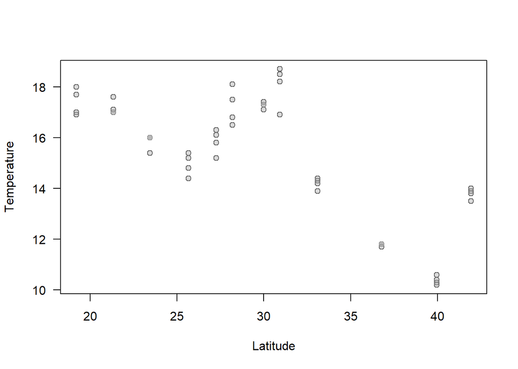

```r
# First, examine a simple scatter plot (always a good idea!)
   plot(Environmental_2$Latitude, Environmental_2$Temperature, xlab = "Latitude", ylab = "Temperature", las=1)
   mygrey <- grey(level = 0.65, alpha = 0.4)
   points(Environmental_2$Latitude, Environmental_2$Temperature, pch = 21, col = mygrey, bg = mygrey)
```

```r
T_mod1 <- mgcv::gam(Temperature ~ s(Latitude), data= Environmental_2, family = gaussian())
T_mod2 <- mgcv::gam(Temperature ~ s(Latitude), data= Environmental_2, family = Gamma())
T_mod3 <- mgcv::gam(Temperature ~ s(Latitude), data= Environmental_2, family = inverse.gaussian())
```

```r
AICc(T_mod1,T_mod2,T_mod3)
```

```
##              df     AICc
## T_mod1 10.49323 92.95936
## T_mod2 10.79361 87.83173
## T_mod3 10.89346 95.94008
```

T_mod2 is the best fitted model

```r
summary(T_mod2)
```

```
##
## Family: Gamma
## Link function: inverse
##
## Formula:
## Temperature ~ s(Latitude)
##
## Parametric coefficients:
##              Estimate Std. Error t value Pr(>|t|)
## (Intercept) 0.0669789  0.0003234   207.1   <2e-16 ***
## ---
## Signif. codes:  0 '***' 0.001 '**' 0.01 '*' 0.05 '.' 0.1 ' ' 1
##
## Approximate significance of smooth terms:
##               edf Ref.df     F p-value
## s(Latitude) 8.794  8.988 107.4  <2e-16 ***
## ---
## Signif. codes:  0 '***' 0.001 '**' 0.01 '*' 0.05 '.' 0.1 ' ' 1
##
## R-sq.(adj) =  0.945   Deviance explained = 96.7%
## GCV = 0.0013495  Scale est. = 0.0010856  n = 48
```

*b.* Plot predicted relationship

```r
new_data <- data.frame(Latitude = seq(min(Environmental_2$Latitude), max(Environmental_2$Latitude), length.out = 100))
predictions <- predict(T_mod2, newdata = new_data, type = "link", se.fit = TRUE)

# Combine predicted values with new_data
ilink <- family(T_mod2)$linkinv
pred <- cbind(new_data, predictions)
pred <- transform(pred, lwr_ci = ilink(fit - (2 * se.fit)),
                        upr_ci = ilink(fit + (2 * se.fit)),
                        fitted = ilink(fit))
```

```r
# Plot the GAM model predictions
Temperature_plot <- ggplot() +
  geom_jitter(data = Environmental_2, aes(x= Latitude, y=Temperature), width = 0.08, height = 0.03, size = 1, alpha = 0.6) +
  geom_ribbon(data = pred, aes(x = Latitude, y = fitted, ymin = lwr_ci, ymax = upr_ci), alpha = 0.2) +
  geom_line(data = pred, aes(x = Latitude, y = fitted), linewidth = 0.6) +
  Theme1 +
labs( y="Temperature (°C)", x="Latitude (°S)") +
theme(axis.title.x=element_blank(),
        axis.text.x=element_blank())
```

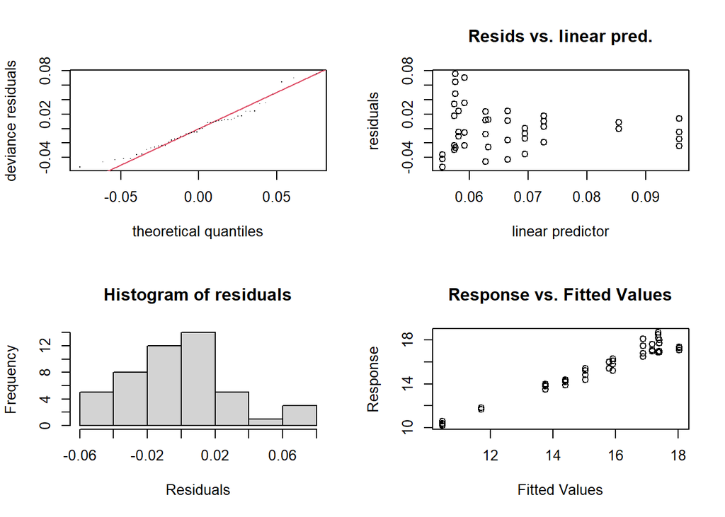

```
##
## Method: GCV   Optimizer: outer newton
## full convergence after 7 iterations.
## Gradient range [2.08852e-11,2.08852e-11]
## (score 0.001349529 & scale 0.001085617).
## Hessian positive definite, eigenvalue range [1.289977e-05,1.289977e-05].
## Model rank =  10 / 10
##
## Basis dimension (k) checking results. Low p-value (k-index<1) may
## indicate that k is too low, especially if edf is close to k'.
##
##               k'  edf k-index p-value
## s(Latitude) 9.00 8.79    0.76   0.055 .
## ---
## Signif. codes:  0 '***' 0.001 '**' 0.01 '*' 0.05 '.' 0.1 ' ' 1
```

```r
par(mfrow = c(2, 2))
gam.check(T_mod2)
```

#### 2) Salinity vs latitude

*a.* Analyses

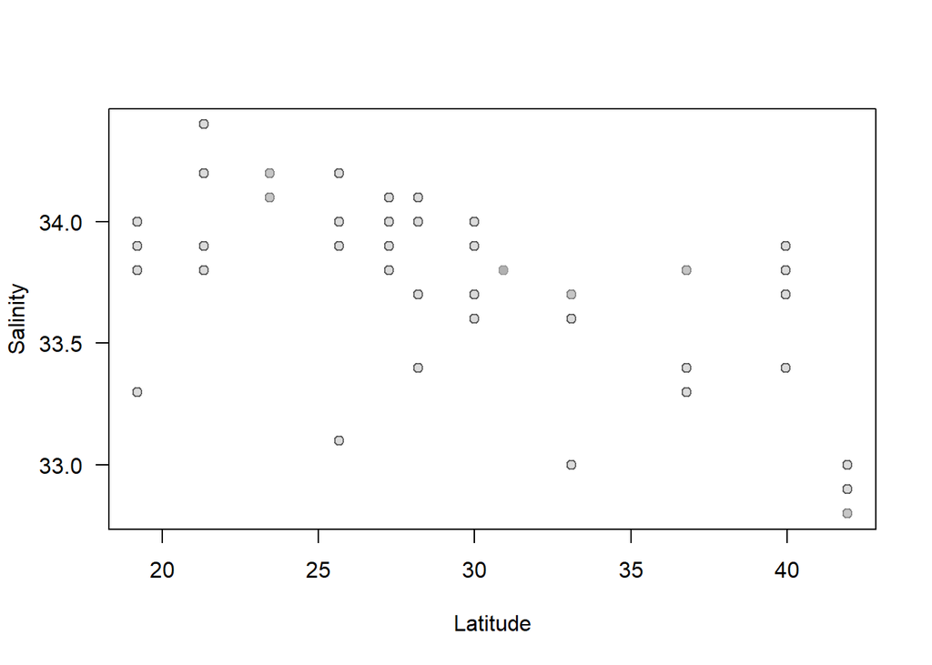

```r
# First, examine a simple scatter plot (always a good idea!)
   plot(Environmental_2$Latitude, Environmental_2$Salinity_ppt, xlab = "Latitude", ylab = "Salinity", las=1)
   mygrey <- grey(level = 0.65, alpha = 0.4)
   points(Environmental_2$Latitude, Environmental_2$Salinity_ppt, pch = 21, col = mygrey, bg = mygrey)
```

```r
S_mod1 <- gam(Salinity_ppt ~ s(Latitude), data= Environmental_2, family = gaussian())
S_mod2 <- gam(Salinity_ppt ~ s(Latitude), data= Environmental_2, family = Gamma())
S_mod3 <- gam(Salinity_ppt ~ s(Latitude), data= Environmental_2, family = inverse.gaussian())
```

```r
AICc(S_mod1, S_mod3, S_mod2)
```

```
##              df     AICc
## S_mod1 8.835490 18.62663
## S_mod3 8.896160 27.17283
## S_mod2 8.875632 19.53924
```

```r
summary(S_mod1)
```

```
##
## Family: gaussian
## Link function: identity
##
## Formula:
## Salinity_ppt ~ s(Latitude)
##
## Parametric coefficients:
##             Estimate Std. Error t value Pr(>|t|)
## (Intercept) 33.73125    0.03678   917.2   <2e-16 ***
## ---
## Signif. codes:  0 '***' 0.001 '**' 0.01 '*' 0.05 '.' 0.1 ' ' 1
##
## Approximate significance of smooth terms:
##               edf Ref.df     F p-value
## s(Latitude) 6.835  7.953 8.194   2e-06 ***
## ---
## Signif. codes:  0 '***' 0.001 '**' 0.01 '*' 0.05 '.' 0.1 ' ' 1
##
## R-sq.(adj) =  0.569   Deviance explained = 63.2%
## GCV = 0.077583  Scale est. = 0.064918  n = 48
```

*b.* Plot predicted relationship

```r
new_data <- data.frame(Latitude = seq(min(Environmental_2$Latitude), max(Environmental_2$Latitude), length.out = 100))
predictions <- predict(S_mod1, newdata = new_data, type = "link", se.fit = TRUE)

# Combine predicted values with new_data
ilink <- family(S_mod1)$linkinv
pred <- cbind(new_data, predictions)
pred <- transform(pred, lwr_ci = ilink(fit - (2 * se.fit)),
                        upr_ci = ilink(fit + (2 * se.fit)),
                        fitted = ilink(fit))
```

```r
# Plot the GAM model predictions
Salinity_plot <- ggplot() +
  geom_jitter(data = Environmental_2, aes(x= Latitude, y=Salinity_ppt), width = 0.08, height = 0.05, size = 1, alpha = 0.6) +
  geom_ribbon(data = pred, aes(x = Latitude, y = fitted, ymin = lwr_ci, ymax = upr_ci), alpha = 0.2) +
  geom_line(data = pred, aes(x = Latitude, y = fitted), linewidth = 0.6) +
  Theme1 +
labs( y="Salinity (ppt)", x="Latitude (°S)") +
theme(axis.title.x=element_blank(),
        axis.text.x=element_blank())
```

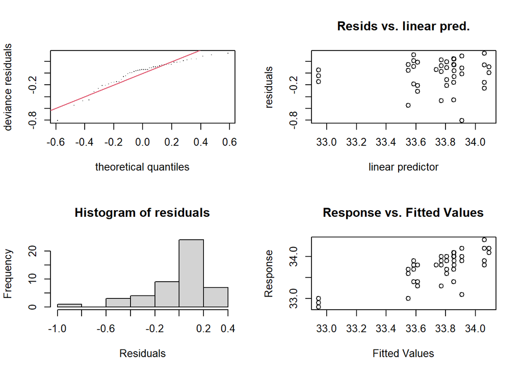

```
##
## Method: GCV   Optimizer: magic
## Smoothing parameter selection converged after 9 iterations.
## The RMS GCV score gradient at convergence was 1.068683e-07 .
## The Hessian was positive definite.
## Model rank =  10 / 10
##
## Basis dimension (k) checking results. Low p-value (k-index<1) may
## indicate that k is too low, especially if edf is close to k'.
##
##               k'  edf k-index p-value
## s(Latitude) 9.00 6.84    1.37    0.99
```

```r
par(mfrow = c(2, 2))
gam.check(S_mod1)
```

#### 3) Oxygen vs latitude

*a.* Analyses

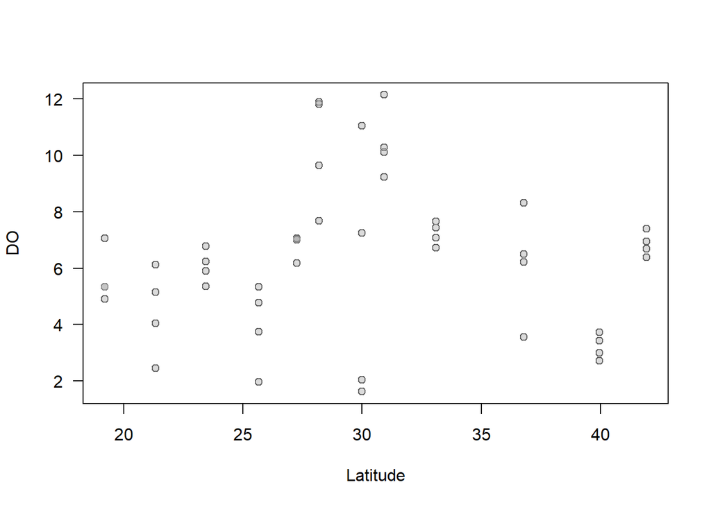

```r
# First, examine a simple scatter plot (always a good idea!)
   plot(Environmental_2$Latitude, Environmental_2$D_oxygen_mgL, xlab = "Latitude", ylab = "DO", las=1)
   mygrey <- grey(level = 0.65, alpha = 0.4)
   points(Environmental_2$Latitude, Environmental_2$D_oxygen_mgL, pch = 21, col = mygrey, bg = mygrey)
```

```r
Ox_mod1 <- gam(D_oxygen_mgL ~ s(Latitude), data= Environmental_2, family = gaussian())
Ox_mod2 <- gam(D_oxygen_mgL ~ s(Latitude), data= Environmental_2, family = Gamma())
Ox_mod3 <- gam(D_oxygen_mgL ~ s(Latitude), data= Environmental_2, family = inverse.gaussian())
```

```r
AICc(Ox_mod1, Ox_mod2, Ox_mod3)
```

```
##               df     AICc
## Ox_mod1 8.700722 226.6735
## Ox_mod2 9.661964 230.3983
## Ox_mod3 4.230413 210.4661
```

Two options may be possible based on AICc. Very low df in Ox_mod 3

```r
summary( Ox_mod1)
```

```
##
## Family: gaussian
## Link function: identity
##
## Formula:
## D_oxygen_mgL ~ s(Latitude)
##
## Parametric coefficients:
##             Estimate Std. Error t value Pr(>|t|)
## (Intercept)    6.381      0.322   19.82   <2e-16 ***
## ---
## Signif. codes:  0 '***' 0.001 '**' 0.01 '*' 0.05 '.' 0.1 ' ' 1
##
## Approximate significance of smooth terms:
##               edf Ref.df     F p-value
## s(Latitude) 6.701  7.838 2.711  0.0183 *
## ---
## Signif. codes:  0 '***' 0.001 '**' 0.01 '*' 0.05 '.' 0.1 ' ' 1
##
## R-sq.(adj) =  0.279   Deviance explained = 38.1%
## GCV = 5.9291  Scale est. = 4.9779    n = 48
```

Deviance explained in Ox_mod3_12 is too low compared to the other. Then, Ox_mod1_12 was chosen

*b.* Plot predicted relationship

```r
new_data <- data.frame(Latitude = seq(min(Environmental_2$Latitude), max(Environmental_2$Latitude), length.out = 100))
predictions <- predict(Ox_mod1, newdata = new_data, type = "link", se.fit = TRUE)

# Combine predicted values with new_data
ilink <- family(Ox_mod1)$linkinv
pred <- cbind(new_data, predictions)
pred <- transform(pred, lwr_ci = ilink(fit - (2 * se.fit)),
                        upr_ci = ilink(fit + (2 * se.fit)),
                        fitted = ilink(fit))
```

```r
# Plot the GAM model predictions
Oxygen_plot <- ggplot() +
  geom_jitter(data = Environmental_2, aes(x= Latitude, y=D_oxygen_mgL), width = 0.08, height = 0.07, size = 1, alpha = 0.6) +
  geom_ribbon(data = pred, aes(x = Latitude, y = fitted, ymin = lwr_ci, ymax = upr_ci), alpha = 0.2) +
  geom_line(data = pred, aes(x = Latitude, y = fitted), linewidth = 0.6) +
  Theme1 +
labs( y="Dissolved oxygen (mgL)", x="Latitude (°S)") +
theme(axis.title.x=element_text(size = 10),
        axis.text.x=element_text(size = 10), axis.text.y = element_text(size = 10), axis.title.y = element_text(size = 8))
```

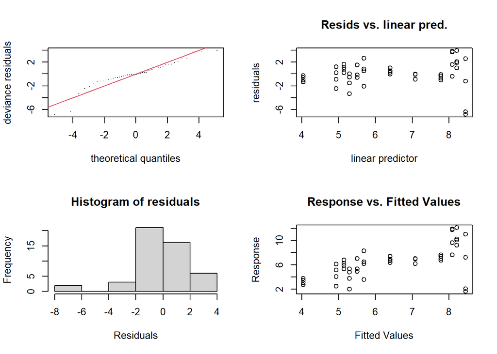

```
##
## Method: GCV   Optimizer: magic
## Smoothing parameter selection converged after 7 iterations.
## The RMS GCV score gradient at convergence was 3.970196e-05 .
## The Hessian was positive definite.
## Model rank =  10 / 10
##
## Basis dimension (k) checking results. Low p-value (k-index<1) may
## indicate that k is too low, especially if edf is close to k'.
##
##              k' edf k-index p-value
## s(Latitude) 9.0 6.7    0.73    0.04 *
## ---
## Signif. codes:  0 '***' 0.001 '**' 0.01 '*' 0.05 '.' 0.1 ' ' 1
```

```r
par(mfrow = c(2, 2))
gam.check(Ox_mod1)
```

#### 4) Visibility vs latitude

*a.* Analyses

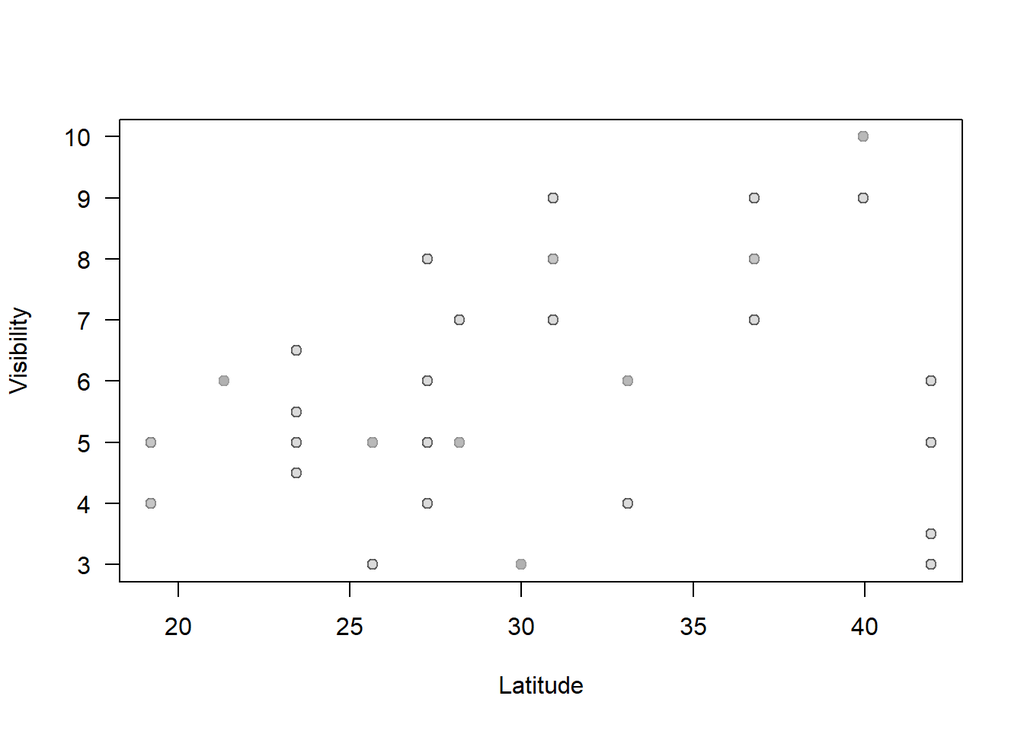

```r
# First, examine a simple scatter plot (always a good idea!)
   plot(Environmental_2$Latitude, Environmental_2$V_Visibility, xlab = "Latitude", ylab = "Visibility", las=1)
   mygrey <- grey(level = 0.65, alpha = 0.4)
   points(Environmental_2$Latitude, Environmental_2$V_Visibility, pch = 21, col = mygrey, bg = mygrey)
```

```r
V_mod1 <- gam(V_Visibility ~ s(Latitude),gamma=1.4, data= Environmental_2, family = gaussian())
V_mod2 <- gam(V_Visibility ~ s(Latitude), data= Environmental_2, family = inverse.gaussian())
V_mod3 <- gam(V_Visibility ~ s(Latitude), data= Environmental_2, family = Gamma())
```

```r
AICc(V_mod1, V_mod2, V_mod3)
```

```
##              df     AICc
## V_mod1 8.590546 187.0415
## V_mod2 7.856608 195.2612
## V_mod3 8.317530 191.4637
```

V_mod1_12 is the best fitted

```r
summary(V_mod1)
```

```
##
## Family: gaussian
## Link function: identity
##
## Formula:
## V_Visibility ~ s(Latitude)
##
## Parametric coefficients:
##             Estimate Std. Error t value Pr(>|t|)
## (Intercept)   5.8542     0.2136   27.41   <2e-16 ***
## ---
## Signif. codes:  0 '***' 0.001 '**' 0.01 '*' 0.05 '.' 0.1 ' ' 1
##
## Approximate significance of smooth terms:
##               edf Ref.df     F  p-value
## s(Latitude) 6.591  7.741 5.224 0.000246 ***
## ---
## Signif. codes:  0 '***' 0.001 '**' 0.01 '*' 0.05 '.' 0.1 ' ' 1
##
## R-sq.(adj) =   0.45   Deviance explained = 52.7%
## GCV = 3.0404  Scale est. = 2.1894    n = 48
```

*b.* Plot predicted relationship

```r
new_data <- data.frame(Latitude = seq(min(Environmental_2$Latitude), max(Environmental_2$Latitude), length.out = 100))
predictions <- predict(V_mod1, newdata = new_data, type = "link", se.fit = TRUE)

# Combine predicted values with new_data
ilink <- family(V_mod1)$linkinv
pred <- cbind(new_data, predictions)
pred <- transform(pred, lwr_ci = ilink(fit - (2 * se.fit)),
                        upr_ci = ilink(fit + (2 * se.fit)),
                        fitted = ilink(fit))
```

```r
# Plot the GAM model predictions
Visibility_plot <- ggplot() +
  geom_jitter(data = Environmental_2, aes(x= Latitude, y=V_Visibility), width = 0.08, height = 0.08, size = 1, alpha = 0.6) +
  geom_ribbon(data = pred, aes(x = Latitude, y = fitted, ymin = lwr_ci, ymax = upr_ci), alpha = 0.2) +
  geom_line(data = pred, aes(x = Latitude, y = fitted), linewidth = 0.6) +
  Theme1 +
labs( y="Visibility (m)", x="Latitude (°S)") +
theme(axis.title.x=element_blank(),
        axis.text.x=element_blank())
```

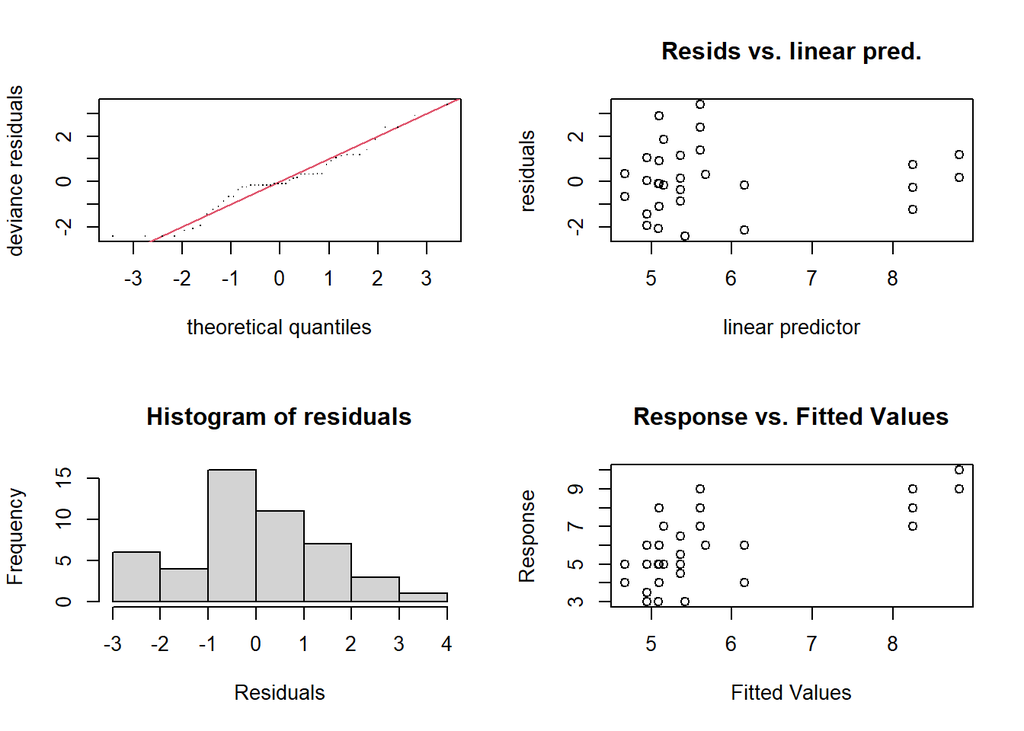

```
##
## Method: GCV   Optimizer: magic
## Smoothing parameter selection converged after 9 iterations.
## The RMS GCV score gradient at convergence was 4.595236e-06 .
## The Hessian was positive definite.
## Model rank =  10 / 10
##
## Basis dimension (k) checking results. Low p-value (k-index<1) may
## indicate that k is too low, especially if edf is close to k'.
##
##               k'  edf k-index p-value
## s(Latitude) 9.00 6.59    0.68    0.01 **
## ---
## Signif. codes:  0 '***' 0.001 '**' 0.01 '*' 0.05 '.' 0.1 ' ' 1
```

```r
par(mfrow = c(2, 2))
gam.check(V_mod1)
```

#### 5) PCOA vs latitude

*a.* Analyses

```r
pcoa_df$Latitude <- pcoa_df$Latitude*-1
```

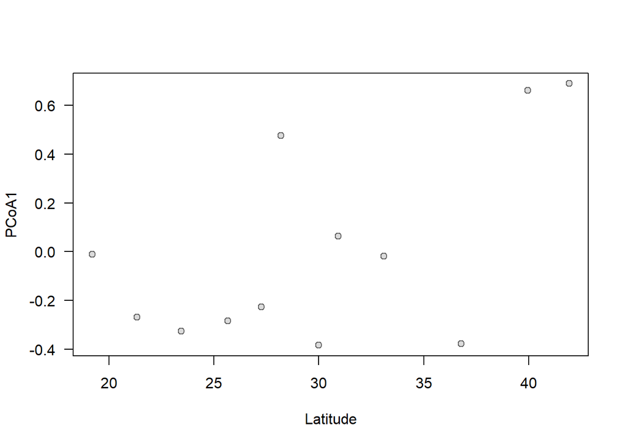

```r
# First, examine a simple scatter plot (always a good idea!)
   plot(pcoa_df$Latitude, pcoa_df$PCo1, xlab = "Latitude", ylab = "PCoA1", las=1)
   mygrey <- grey(level = 0.65, alpha = 0.4)
   points(pcoa_df$Latitude, pcoa_df$PCo1, pch = 21, col = mygrey, bg = mygrey)
```

```r
PCO_mod1 <- gam(PCo1~ s(Latitude), gamma= 1.4, data= pcoa_df,  family = gaussian())
```

```r
AICc(PCO_mod1)
```

```
## [1] 15.22301
```

```r
summary(PCO_mod1)
```

```
##
## Family: gaussian
## Link function: identity
##
## Formula:
## PCo1 ~ s(Latitude)
##
## Parametric coefficients:
##              Estimate Std. Error t value Pr(>|t|)
## (Intercept) 3.205e-17  9.808e-02       0        1
##
## Approximate significance of smooth terms:
##              edf Ref.df     F p-value
## s(Latitude) 1.09  1.173 4.554  0.0634 .
## ---
## Signif. codes:  0 '***' 0.001 '**' 0.01 '*' 0.05 '.' 0.1 ' ' 1
##
## R-sq.(adj) =  0.271   Deviance explained = 34.3%
## GCV = 0.1667  Scale est. = 0.11543   n = 12
```

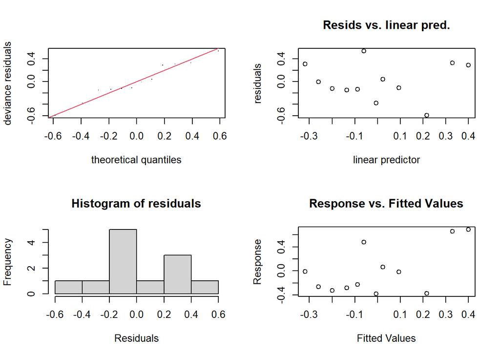

```
##
## Method: GCV   Optimizer: magic
## Smoothing parameter selection converged after 9 iterations.
## The RMS GCV score gradient at convergence was 3.007551e-06 .
## The Hessian was positive definite.
## Model rank =  10 / 10
##
## Basis dimension (k) checking results. Low p-value (k-index<1) may
## indicate that k is too low, especially if edf is close to k'.
##
##               k'  edf k-index p-value
## s(Latitude) 9.00 1.09    1.29    0.72
```

```r
par(mfrow = c(2, 2))
gam.check(PCO_mod1)
```

*No significant effect*

```r
# Plot the GAM model predictions
PCOA_plot <- ggplot() +
  geom_jitter(data = pcoa_df, aes(x= Latitude, y=PCo1), width = 0, height = 0, size = 1, alpha = 0.6) +
  Theme1 +
labs( y="PCoA1", x="Latitude (°S)")
```

#### 6) Kelp vs latitude

*a.* Analyses

*For further plotting*

```r
Benthic_metadata_wide$Latitude <- Benthic_metadata_wide$Latitude*-1
```

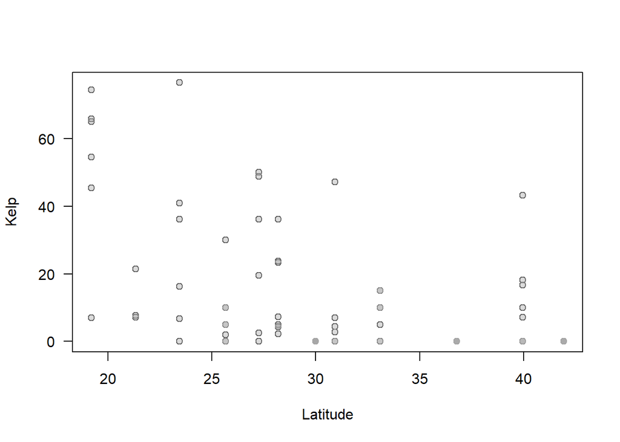

```r
# First, examine a simple scatter plot (always a good idea!)
   plot(Benthic_metadata_wide$Latitude, Benthic_metadata_wide$Kelp, xlab = "Latitude", ylab = "Kelp", las=1)
   mygrey <- grey(level = 0.65, alpha = 0.4)
   points(Benthic_metadata_wide$Latitude, Benthic_metadata_wide$Kelp, pch = 21, col = mygrey, bg = mygrey)
```

```r
Kelp_mod1 <- mgcv::gam(Kelp ~ s(Latitude), gamma = 1.4, data = Benthic_metadata_wide, family = gaussian())
Kelp_mod2 <- mgcv::gam(Kelp ~ s(Latitude), gamma =1.4, data = Benthic_metadata_wide, family = tw())
```

```r
AICc(Kelp_mod2, Kelp_mod1)
```

```
##                 df     AICc
## Kelp_mod2 4.640437 476.8968
## Kelp_mod1 4.217000 663.0220
```

```r
summary(Kelp_mod2)
```

```
##
## Family: Tweedie(p=1.365)
## Link function: log
##
## Formula:
## Kelp ~ s(Latitude)
##
## Parametric coefficients:
##             Estimate Std. Error t value Pr(>|t|)
## (Intercept)    2.351      0.156   15.07   <2e-16 ***
## ---
## Signif. codes:  0 '***' 0.001 '**' 0.01 '*' 0.05 '.' 0.1 ' ' 1
##
## Approximate significance of smooth terms:
##               edf Ref.df    F  p-value
## s(Latitude) 1.367   1.64 13.1 4.69e-05 ***
## ---
## Signif. codes:  0 '***' 0.001 '**' 0.01 '*' 0.05 '.' 0.1 ' ' 1
##
## R-sq.(adj) =   0.33   Deviance explained = 24.4%
## -REML = 169.53  Scale est. = 7.6607    n = 78
```

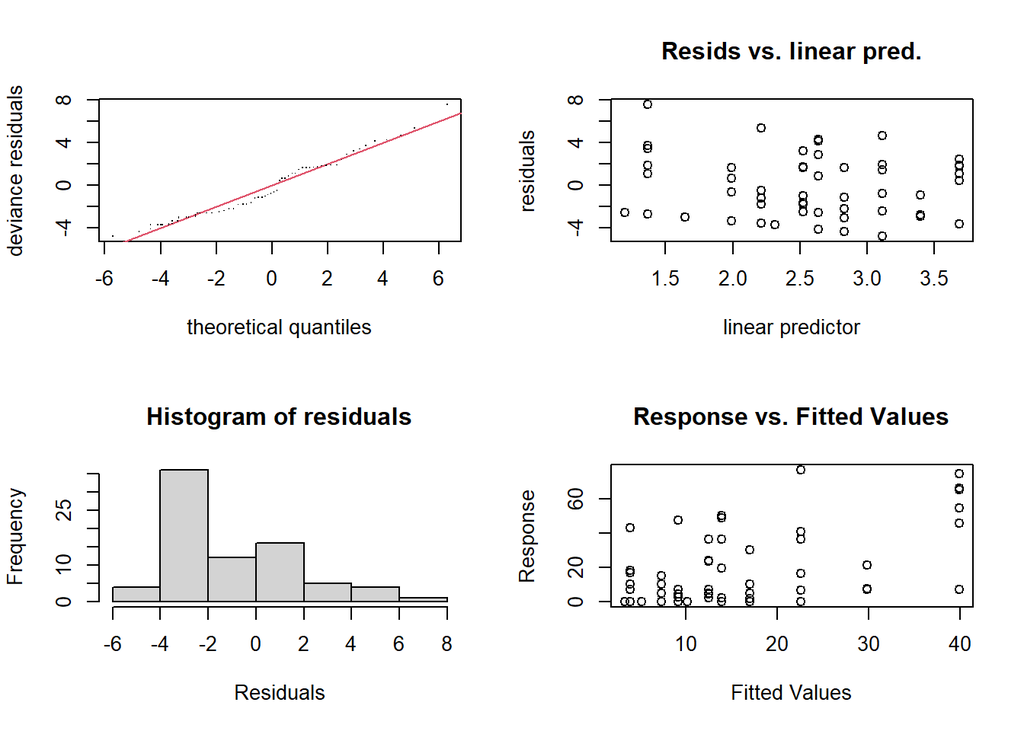

```
##
## Method: REML   Optimizer: outer newton
## full convergence after 8 iterations.
## Gradient range [-2.196392e-05,1.485091e-05]
## (score 169.5299 & scale 7.660684).
## Hessian positive definite, eigenvalue range [0.06262817,51.51969].
## Model rank =  10 / 10
##
## Basis dimension (k) checking results. Low p-value (k-index<1) may
## indicate that k is too low, especially if edf is close to k'.
##
##               k'  edf k-index p-value
## s(Latitude) 9.00 1.37    0.79    0.12
```

```r
par(mfrow = c(2, 2))
gam.check(Kelp_mod2)
```

*b.* Plot predicted relationship

```r
new_data <- data.frame(Latitude = seq(min(Benthic_metadata_wide$Latitude), max(Benthic_metadata_wide$Latitude), length.out = 100))
predictions <- predict(Kelp_mod2, newdata = new_data, type = "link", se.fit = TRUE)

# Combine predicted values with new_data
ilink <- family(Kelp_mod2)$linkinv
pred <- cbind(new_data, predictions)
pred <- transform(pred, lwr_ci = ilink(fit - (2 * se.fit)),
                        upr_ci = ilink(fit + (2 * se.fit)),
                        fitted = ilink(fit))
```

```r
# Plot the GAM model predictions
Kelp_plot <- ggplot() +
  geom_jitter(data = Benthic_metadata_wide, aes(x= Latitude, y=Kelp), width = 0.08, height = 0.11, size = 1, alpha = 0.6) +
  geom_ribbon(data = pred, aes(x = Latitude, y = fitted, ymin = lwr_ci, ymax = upr_ci), alpha = 0.2) +
  geom_line(data = pred, aes(x = Latitude, y = fitted), linewidth = 0.6) +
  Theme1 +
labs( y="Kelp cover (%)", x="Latitude (°S)") +
theme(axis.title.x=element_blank(),
        axis.text.x=element_blank())
```

#### 7) Bare_rock vs latitude

*a.* Analyses

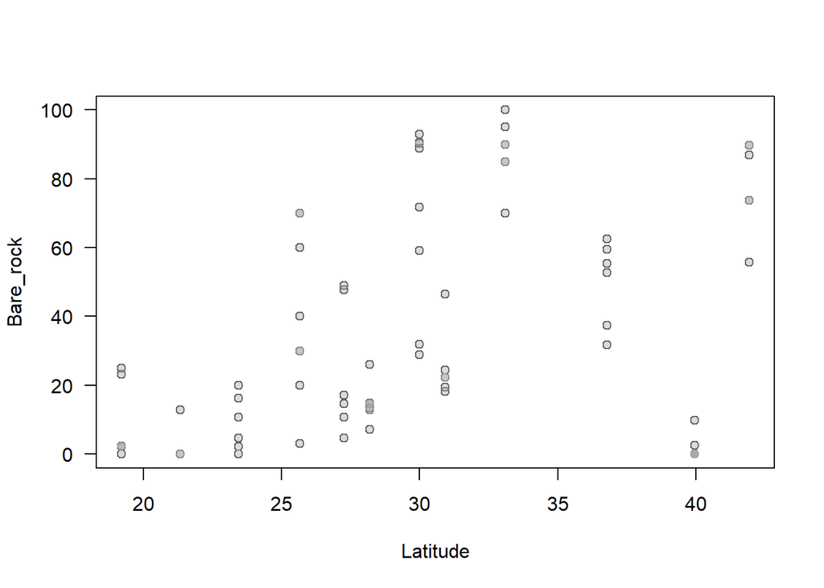

```r
# First, examine a simple scatter plot (always a good idea!)
   plot(Benthic_metadata_wide$Latitude, Benthic_metadata_wide$Bare_rock, xlab = "Latitude", ylab = "Bare_rock", las=1)
   mygrey <- grey(level = 0.65, alpha = 0.4)
   points(Benthic_metadata_wide$Latitude, Benthic_metadata_wide$Bare_rock, pch = 21, col = mygrey, bg = mygrey)
```

```r
BR_mod1 <- mgcv::gam(Bare_rock ~ s(Latitude), gamma= 1.4, data = Benthic_metadata_wide, family = gaussian())
BR_mod2 <- mgcv::gam(Bare_rock ~ s(Latitude), gamma=1.4, data = Benthic_metadata_wide, family = tw())
```

```r
AICc(BR_mod1, BR_mod2)
```

```
##                df     AICc
## BR_mod1  9.728495 706.3690
## BR_mod2 11.606470 637.8918
```

```r
summary(BR_mod2)
```

```
##
## Family: Tweedie(p=1.3)
## Link function: log
##
## Formula:
## Bare_rock ~ s(Latitude)
##
## Parametric coefficients:
##             Estimate Std. Error t value Pr(>|t|)
## (Intercept)  3.20356    0.08913   35.94   <2e-16 ***
## ---
## Signif. codes:  0 '***' 0.001 '**' 0.01 '*' 0.05 '.' 0.1 ' ' 1
##
## Approximate significance of smooth terms:
##               edf Ref.df     F p-value
## s(Latitude) 7.926  8.606 12.08  <2e-16 ***
## ---
## Signif. codes:  0 '***' 0.001 '**' 0.01 '*' 0.05 '.' 0.1 ' ' 1
##
## R-sq.(adj) =  0.598   Deviance explained = 62.8%
## -REML = 238.88  Scale est. = 4.7114    n = 78
```

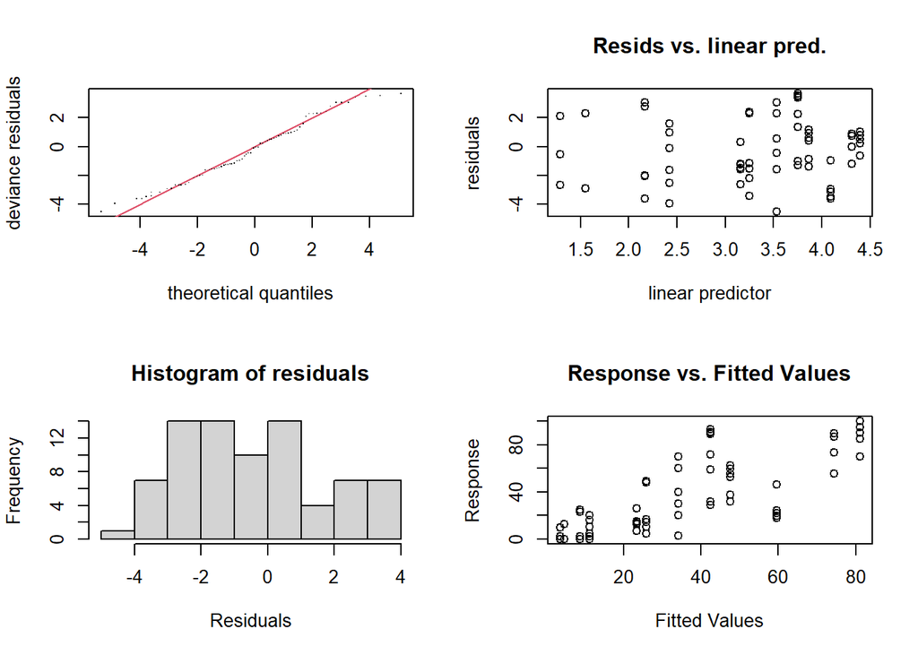

```
##
## Method: REML   Optimizer: outer newton
## full convergence after 7 iterations.
## Gradient range [-1.240802e-07,7.992647e-07]
## (score 238.878 & scale 4.711392).
## Hessian positive definite, eigenvalue range [1.777301,45.39948].
## Model rank =  10 / 10
##
## Basis dimension (k) checking results. Low p-value (k-index<1) may
## indicate that k is too low, especially if edf is close to k'.
##
##               k'  edf k-index p-value
## s(Latitude) 9.00 7.93    0.75   0.015 *
## ---
## Signif. codes:  0 '***' 0.001 '**' 0.01 '*' 0.05 '.' 0.1 ' ' 1
```

```r
par(mfrow = c(2, 2))
gam.check(BR_mod2)
```

*b.* Plot predicted relationship

```r
new_data <- data.frame(Latitude = seq(min(Benthic_metadata_wide$Latitude), max(Benthic_metadata_wide$Latitude), length.out = 100))
predictions <- predict(BR_mod2, newdata = new_data, type = "link", se.fit = TRUE)

# Combine predicted values with new_data
ilink <- family(BR_mod2)$linkinv
pred <- cbind(new_data, predictions)
pred <- transform(pred, lwr_ci = ilink(fit - (2 * se.fit)),
                        upr_ci = ilink(fit + (2 * se.fit)),
                        fitted = ilink(fit))
```

```r
# Plot the GAM model predictions
Bare_plot <- ggplot() +
  geom_jitter(data = Benthic_metadata_wide, aes(x= Latitude, y=Bare_rock), width = 0.08, height = 0.11, size = 1, alpha = 0.6) +
  geom_ribbon(data = pred, aes(x = Latitude, y = fitted, ymin = lwr_ci, ymax = upr_ci), alpha = 0.2) +
  geom_line(data = pred, aes(x = Latitude, y = fitted), linewidth = 0.6) +
  Theme1 +
labs( y="Bare rock cover(%)", x="Latitude (°S)") +
theme(axis.title.x=element_blank(),
        axis.text.x=element_blank())
```

#### 8) Predatory fish abundance vs latitude

```r
TransectGroup_wide$Latitude <- TransectGroup_wide$Latitude*-1
```

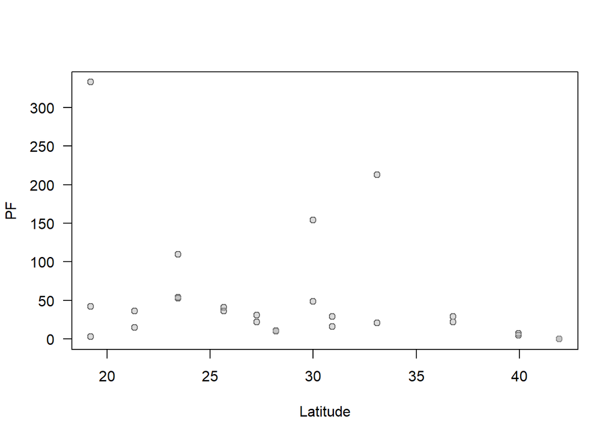

```r
# First, examine a simple scatter plot (always a good idea!)
   plot(TransectGroup_wide$Latitude, TransectGroup_wide$Predatory_fish, xlab = "Latitude", ylab = "PF", las=1)
   mygrey <- grey(level = 0.65, alpha = 0.4)
   points(TransectGroup_wide$Latitude, TransectGroup_wide$Predatory_fish, pch = 21, col = mygrey, bg = mygrey)
```

```r
PF_mod1 <- mgcv::gam(Predatory_fish ~ s(Latitude), gamma=1.4, data = TransectGroup_wide, family =poisson)
PF_mod2 <- mgcv::gam(Predatory_fish ~ s(Latitude), gamma=1.4, data = TransectGroup_wide, family =quasipoisson)
PF_mod3 <- mgcv::gam(Predatory_fish ~ s(Latitude), gamma=1.4, data = TransectGroup_wide, family =nb)
```

```r
AICc(PF_mod2, PF_mod1, PF_mod3)
```

```
##               df      AICc
## PF_mod2 4.624668        NA
## PF_mod1 9.516203 1174.2311
## PF_mod3 6.155803  252.0494
```

```r
summary(PF_mod3)
```

```
##
## Family: Negative Binomial(1.038)
## Link function: log
##
## Formula:
## Predatory_fish ~ s(Latitude)
##
## Parametric coefficients:
##             Estimate Std. Error z value Pr(>|z|)
## (Intercept)   3.4929     0.2019    17.3   <2e-16 ***
## ---
## Signif. codes:  0 '***' 0.001 '**' 0.01 '*' 0.05 '.' 0.1 ' ' 1
##
## Approximate significance of smooth terms:
##               edf Ref.df Chi.sq  p-value
## s(Latitude) 3.351  4.156  30.09 6.78e-06 ***
## ---
## Signif. codes:  0 '***' 0.001 '**' 0.01 '*' 0.05 '.' 0.1 ' ' 1
##
## R-sq.(adj) =  0.0722   Deviance explained = 49.6%
## -REML = 89.213  Scale est. = 1         n = 26
```

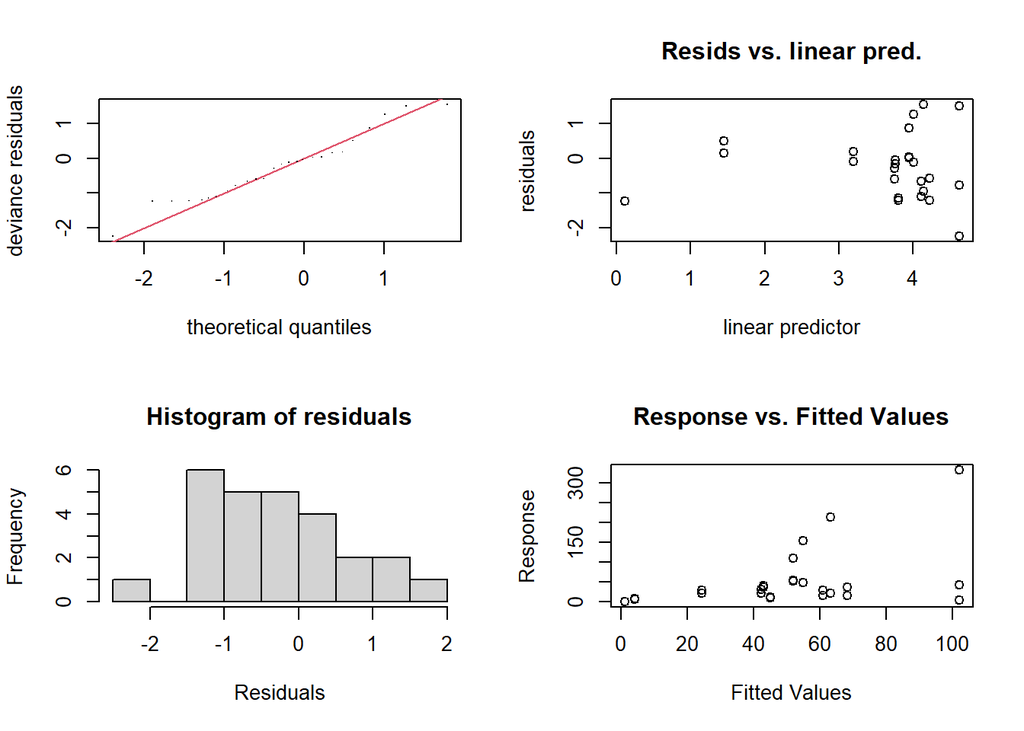

```
##
## Method: REML   Optimizer: outer newton
## full convergence after 2 iterations.
## Gradient range [-1.29827e-07,5.38212e-07]
## (score 89.21338 & scale 1).
## Hessian positive definite, eigenvalue range [0.604836,7.703663].
## Model rank =  10 / 10
##
## Basis dimension (k) checking results. Low p-value (k-index<1) may
## indicate that k is too low, especially if edf is close to k'.
##
##               k'  edf k-index p-value
## s(Latitude) 9.00 3.35    1.03    0.67
```

```r
par(mfrow = c(2, 2))
gam.check(PF_mod3)
```

*b.* Plot predicted relationship

```r
new_data <- data.frame(Latitude = seq(min(TransectGroup_wide$Latitude), max(TransectGroup_wide$Latitude), length.out = 100))
predictions <- predict(PF_mod3, newdata = new_data, type = "link", se.fit = TRUE)

# Combine predicted values with new_data
ilink <- family(PF_mod3)$linkinv
pred <- cbind(new_data, predictions)
pred <- transform(pred, lwr_ci = ilink(fit - (2 * se.fit)),
                        upr_ci = ilink(fit + (2 * se.fit)),
                        fitted = ilink(fit))
```

```r
# Plot the GAM model predictions
PredFish_plot <- ggplot() +
  geom_jitter(data = TransectGroup_wide, aes(x= Latitude, y=Predatory_fish), width = 0.12, height = 0.5, size = 1, alpha = 0.6) +
  geom_ribbon(data = pred, aes(x = Latitude, y = fitted, ymin = lwr_ci, ymax = upr_ci), alpha = 0.2) +
  geom_line(data = pred, aes(x = Latitude, y = fitted), linewidth = 0.6) +
  Theme1 +
labs( y="Predatory Fish", x="Latitude (°S)") +
theme(axis.title.x=element_blank(),
        axis.text.x=element_blank())
```

#### 9) Herbivorous fish abundance vs latitude

*a.* Analyses

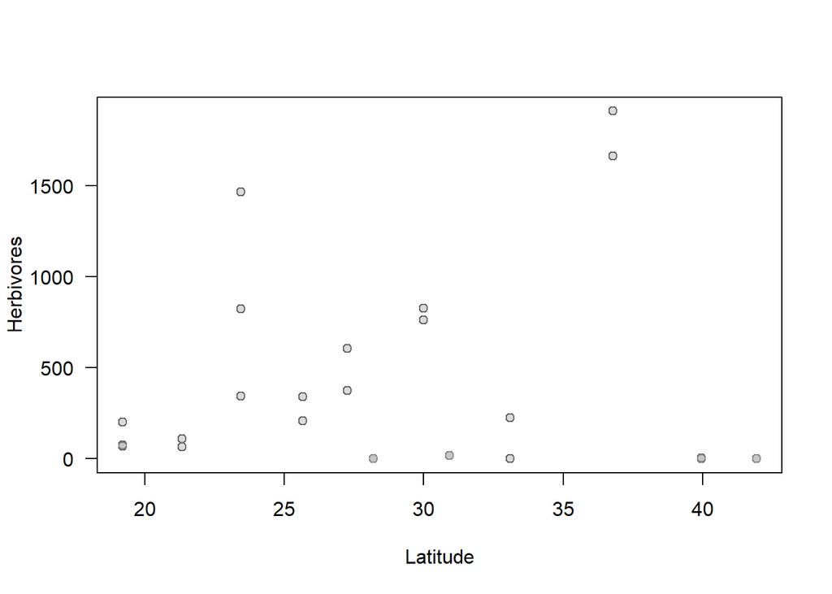

```r
# First, examine a simple scatter plot (always a good idea!)
   plot(TransectGroup_wide$Latitude, TransectGroup_wide$Herbivores, xlab = "Latitude", ylab = "Herbivores", las=1)
   mygrey <- grey(level = 0.65, alpha = 0.4)
   points(TransectGroup_wide$Latitude, TransectGroup_wide$Herbivores, pch = 21, col = mygrey, bg = mygrey)
```

```r
Herb_mod1 <- mgcv::gam(Herbivores ~ s(Latitude), gamma=1.4, data = TransectGroup_wide, family =poisson())
Herb_mod2 <- mgcv::gam(Herbivores ~ s(Latitude), gamma=1.4, data = TransectGroup_wide, family =quasipoisson())
Herb_mod3 <- mgcv::gam(Herbivores ~ s(Latitude), gamma=1.4, data = TransectGroup_wide, family =nb())
```

```r
AICc(Herb_mod1, Herb_mod2, Herb_mod3)
```

```
##                 df      AICc
## Herb_mod1 9.983415 4296.9233
## Herb_mod2 8.545300        NA
## Herb_mod3 7.826680  333.2693
```

```r
summary(Herb_mod3)
```

```
##
## Family: Negative Binomial(0.454)
## Link function: log
##
## Formula:
## Herbivores ~ s(Latitude)
##
## Parametric coefficients:
##             Estimate Std. Error z value Pr(>|z|)
## (Intercept)   4.9115     0.3178   15.45   <2e-16 ***
## ---
## Signif. codes:  0 '***' 0.001 '**' 0.01 '*' 0.05 '.' 0.1 ' ' 1
##
## Approximate significance of smooth terms:
##               edf Ref.df Chi.sq  p-value
## s(Latitude) 4.757  5.827  30.12 3.74e-05 ***
## ---
## Signif. codes:  0 '***' 0.001 '**' 0.01 '*' 0.05 '.' 0.1 ' ' 1
##
## R-sq.(adj) =  0.195   Deviance explained =   50%
## -REML = 117.44  Scale est. = 1         n = 26
```

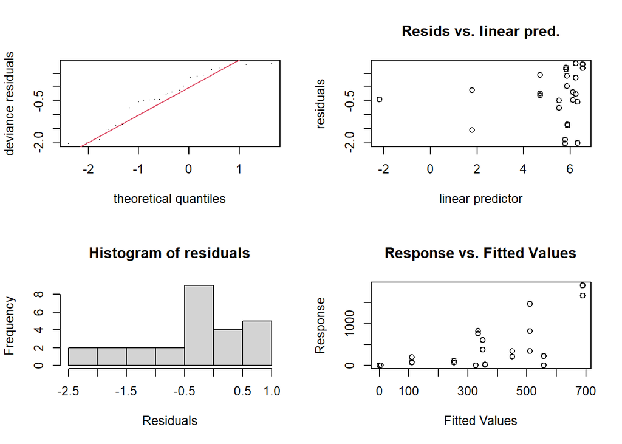

```
##
## Method: REML   Optimizer: outer newton
## full convergence after 6 iterations.
## Gradient range [-3.297643e-09,5.452203e-09]
## (score 117.4409 & scale 1).
## Hessian positive definite, eigenvalue range [0.9303036,8.671097].
## Model rank =  10 / 10
##
## Basis dimension (k) checking results. Low p-value (k-index<1) may
## indicate that k is too low, especially if edf is close to k'.
##
##               k'  edf k-index p-value
## s(Latitude) 9.00 4.76    0.79    0.24
```

```r
par(mfrow = c(2, 2))
gam.check(Herb_mod3)
```

*b.* Plot predicted relationship

```r
new_data <- data.frame(Latitude = seq(min(TransectGroup_wide$Latitude), max(TransectGroup_wide$Latitude), length.out = 100))
predictions <- predict(Herb_mod3, newdata = new_data, type = "link", se.fit = TRUE)

# Combine predicted values with new_data
ilink <- family(Herb_mod3)$linkinv
pred <- cbind(new_data, predictions)
pred <- transform(pred, lwr_ci = ilink(fit - (2 * se.fit)),
                        upr_ci = ilink(fit + (2 * se.fit)),
                        fitted = ilink(fit))
```

```r
# Plot the GAM model predictions
Herb_plot <- ggplot() +
  geom_jitter(data = TransectGroup_wide, aes(x= Latitude, y=Herbivores), width = 0.2, height = 0.5, size = 1, alpha = 0.6) +
  geom_ribbon(data = pred, aes(x = Latitude, y = fitted, ymin = lwr_ci, ymax = upr_ci), alpha = 0.2) +
  geom_line(data = pred, aes(x = Latitude, y = fitted), linewidth = 0.6) +
  Theme1 +
labs( y="Herbivores", x="Latitude (°S)")
```

#### 10) Invertebrate predators abundance vs latitude

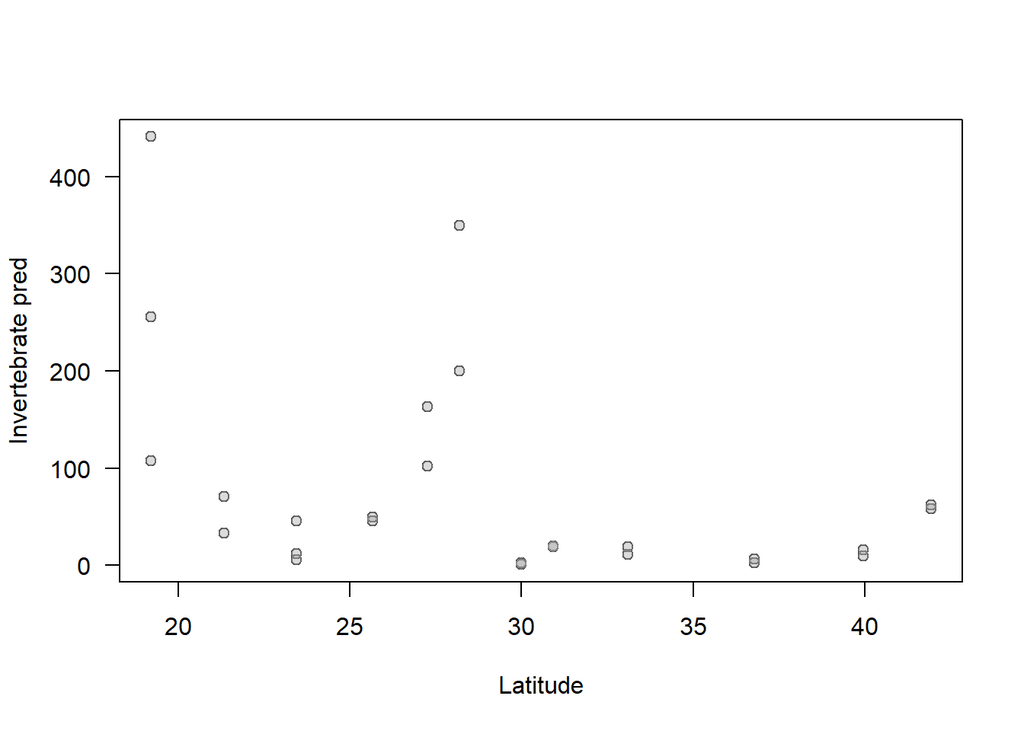

```r
# First, examine a simple scatter plot (always a good idea!)
   plot(TransectGroup_wide$Latitude, TransectGroup_wide$Invertebrate_predators, xlab = "Latitude", ylab = "Invertebrate pred", las=1)
   mygrey <- grey(level = 0.65, alpha = 0.4)
   points(TransectGroup_wide$Latitude, TransectGroup_wide$Invertebrate_predators, pch = 21, col = mygrey, bg = mygrey)
```

```r
Inv_mod1 <- mgcv::gam(Invertebrate_predators ~ s(Latitude), gamma=1.4, data = TransectGroup_wide, family =poisson())
Inv_mod2 <- mgcv::gam(Invertebrate_predators ~ s(Latitude), gamma=1.4, data = TransectGroup_wide, family =quasipoisson())
Inv_mod3 <- mgcv::gam(Invertebrate_predators ~ s(Latitude), gamma=1.4, data = TransectGroup_wide, family = nb())
```

```r
AICc(Inv_mod2, Inv_mod1, Inv_mod3)
```

```
##                df     AICc
## Inv_mod2 7.690064       NA
## Inv_mod1 9.885648 660.0753
## Inv_mod3 8.229799 272.5043
```

```r
summary(Inv_mod3)
```

```
##
## Family: Negative Binomial(1.273)
## Link function: log
##
## Formula:
## Invertebrate_predators ~ s(Latitude)
##
## Parametric coefficients:
##             Estimate Std. Error z value Pr(>|z|)
## (Intercept)   3.7830     0.1779   21.26   <2e-16 ***
## ---
## Signif. codes:  0 '***' 0.001 '**' 0.01 '*' 0.05 '.' 0.1 ' ' 1
##
## Approximate significance of smooth terms:
##               edf Ref.df Chi.sq p-value
## s(Latitude) 5.119   6.23  35.49  <2e-16 ***
## ---
## Signif. codes:  0 '***' 0.001 '**' 0.01 '*' 0.05 '.' 0.1 ' ' 1
##
## R-sq.(adj) =  0.473   Deviance explained = 66.2%
## -REML = 97.611  Scale est. = 1         n = 26
```

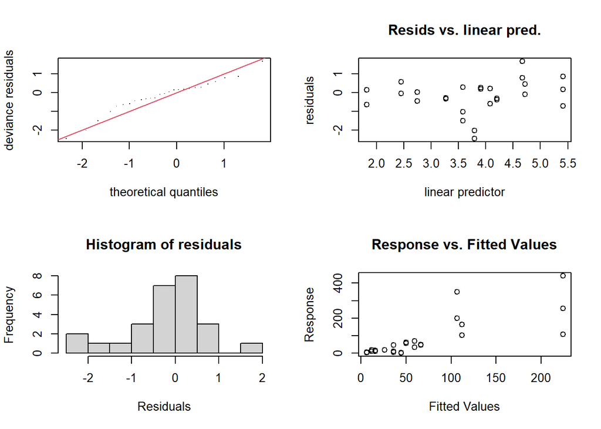

```
##
## Method: REML   Optimizer: outer newton
## full convergence after 4 iterations.
## Gradient range [-5.190965e-05,4.311985e-05]
## (score 97.61055 & scale 1).
## Hessian positive definite, eigenvalue range [0.9545727,6.48156].
## Model rank =  10 / 10
##
## Basis dimension (k) checking results. Low p-value (k-index<1) may
## indicate that k is too low, especially if edf is close to k'.
##
##               k'  edf k-index p-value
## s(Latitude) 9.00 5.12    0.86    0.17
```

```r
par(mfrow = c(2, 2))
gam.check(Inv_mod3)
```

*b.* Plot predicted relationship

```r
new_data <- data.frame(Latitude = seq(min(TransectGroup_wide$Latitude), max(TransectGroup_wide$Latitude), length.out = 100))
predictions <- predict(Inv_mod3, newdata = new_data, type = "link", se.fit = TRUE)

# Combine predicted values with new_data
ilink <- family(Inv_mod3)$linkinv
pred <- cbind(new_data, predictions)
pred <- transform(pred, lwr_ci = ilink(fit - (2 * se.fit)),
                        upr_ci = ilink(fit + (2 * se.fit)),
                        fitted = ilink(fit))
```

```r
# Plot the GAM model predictions
Inv_plot <- ggplot() +
  geom_jitter(data = TransectGroup_wide, aes(x= Latitude, y=Invertebrate_predators), width = 0.08, height = 0.5, size = 1, alpha = 0.6) +
  geom_ribbon(data = pred, aes(x = Latitude, y = fitted, ymin = lwr_ci, ymax = upr_ci), alpha = 0.2) +
  geom_line(data = pred, aes(x = Latitude, y = fitted), linewidth = 0.6) +
  Theme1 +
labs( y="Invertebrate predators", x="Latitude (°S)") +
theme(axis.title.x=element_blank(),
        axis.text.x=element_blank(), axis.title.y = element_text(size = 8))
```

#### 11) Species richness vs latitude

```r
Richness_transect$Latitude <- Richness_transect$Latitude*-1
```

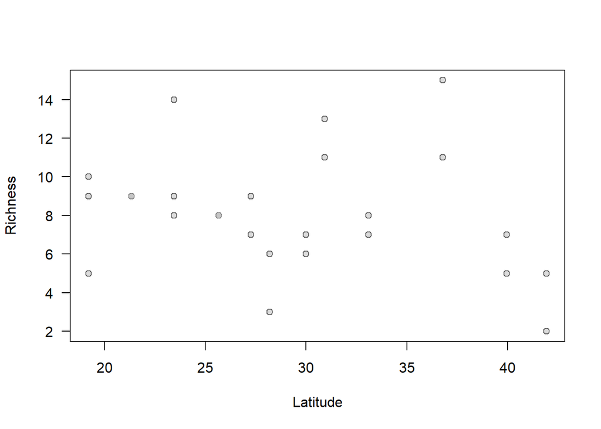

```r
# First, examine a simple scatter plot (always a good idea!)
   plot(Richness_transect$Latitude, Richness_transect$Richness, xlab = "Latitude", ylab = "Richness", las=1)
   mygrey <- grey(level = 0.65, alpha = 0.4)
   points(Richness_transect$Latitude, Richness_transect$Richness, pch = 21, col = mygrey, bg = mygrey)
```

```r
R_mod1 <- mgcv::gam(Richness ~ s(Latitude), gamma=1.4, data = Richness_transect, family =poisson())
R_mod2 <- mgcv::gam(Richness ~ s(Latitude), gamma=1.4,data = Richness_transect, family =nb())
```

```r
AICc(R_mod2, R_mod1)
```

```
##              df     AICc
## R_mod2 3.013601 136.7409
## R_mod1 4.934598 130.7241
```

```r
summary(R_mod1)
```

```
##
## Family: poisson
## Link function: log
##
## Formula:
## Richness ~ s(Latitude)
##
## Parametric coefficients:
##             Estimate Std. Error z value Pr(>|z|)
## (Intercept)  2.07428    0.07004   29.62   <2e-16 ***
## ---
## Signif. codes:  0 '***' 0.001 '**' 0.01 '*' 0.05 '.' 0.1 ' ' 1
##
## Approximate significance of smooth terms:
##               edf Ref.df Chi.sq p-value
## s(Latitude) 3.935  4.855  8.917   0.099 .
## ---
## Signif. codes:  0 '***' 0.001 '**' 0.01 '*' 0.05 '.' 0.1 ' ' 1
##
## R-sq.(adj) =  0.302   Deviance explained = 43.2%
## UBRE = 0.19305  Scale est. = 1         n = 26
```

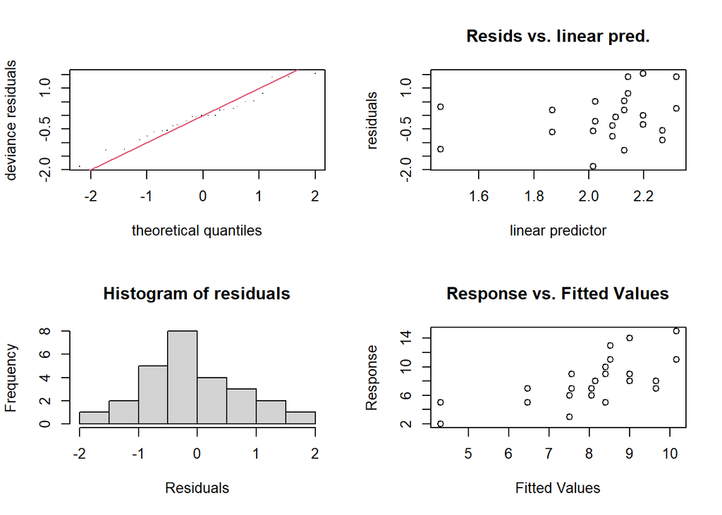

```
##
## Method: UBRE   Optimizer: outer newton
## full convergence after 4 iterations.
## Gradient range [-6.400339e-12,-6.400339e-12]
## (score 0.1930469 & scale 1).
## Hessian positive definite, eigenvalue range [0.06283876,0.06283876].
## Model rank =  10 / 10
##
## Basis dimension (k) checking results. Low p-value (k-index<1) may
## indicate that k is too low, especially if edf is close to k'.
##
##               k'  edf k-index p-value
## s(Latitude) 9.00 3.93    0.98    0.36
```

```r
par(mfrow = c(2, 2))
gam.check(R_mod1)
```

*No significant effect*

```r
# Plot the GAM model predictions
Richness_plot <- ggplot() +
  geom_jitter(data = Richness_transect, aes(x= Latitude, y=Richness), width = 0.08, height = 0.5, size = 1, alpha = 0.6) +
  Theme1 +
labs( y="Species Richness", x="Latitude (°S)") +
theme(axis.title.y = element_text(size = 8))
```

#### 12) Fish length vs latitude

```r
Size_fish <- filter(Size_mean_sp, Type == "Fish")
Size_fish$Latitude <- Size_fish$Latitude*-1
```

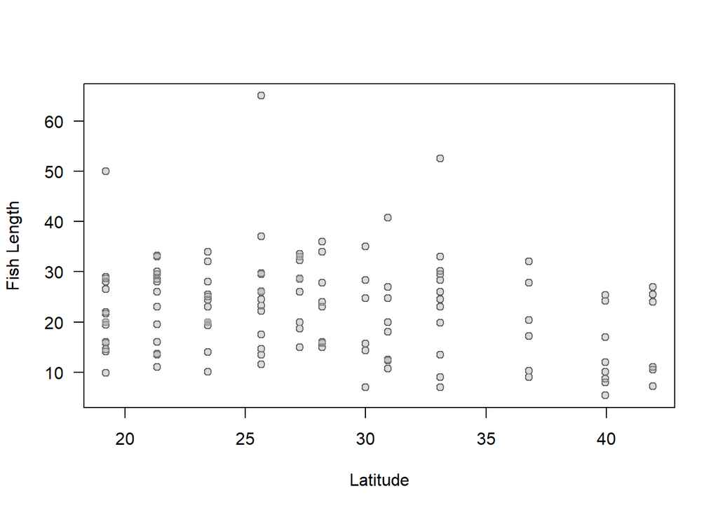

```r
# First, examine a simple scatter plot (always a good idea!)
   plot(Size_fish$Latitude, Size_fish$mean_Size_sp, xlab = "Latitude", ylab = "Fish Length", las=1)
   mygrey <- grey(level = 0.65, alpha = 0.4)
   points(Size_fish$Latitude, Size_fish$mean_Size_sp, pch = 21, col = mygrey, bg = mygrey)
```

```r
Length_mod1 <- mgcv::gam(mean_Size_sp ~ s(Latitude), gamma=1.4, data = Size_fish, family =gaussian())
Length_mod2 <- mgcv::gam(mean_Size_sp ~ s(Latitude), gamma=1.4, data = Size_fish, family =Gamma())
Length_mod3 <- mgcv::gam(mean_Size_sp ~ s(Latitude), gamma=1.4, data = Size_fish, family =inverse.gaussian())
```

```r
AICc(Length_mod1, Length_mod2, Length_mod3)
```

```
##                   df     AICc
## Length_mod1 3.716434 876.0274
## Length_mod2 3.823501 861.9641
## Length_mod3 3.801599 851.5481
```

```r
summary(Length_mod3)
```

```
##
## Family: inverse.gaussian
## Link function: 1/mu^2
##
## Formula:
## mean_Size_sp ~ s(Latitude)
##
## Parametric coefficients:
##              Estimate Std. Error t value Pr(>|t|)
## (Intercept) 0.0020493  0.0001609   12.74   <2e-16 ***
## ---
## Signif. codes:  0 '***' 0.001 '**' 0.01 '*' 0.05 '.' 0.1 ' ' 1
##
## Approximate significance of smooth terms:
##               edf Ref.df     F p-value
## s(Latitude) 1.802  2.244 3.408  0.0305 *
## ---
## Signif. codes:  0 '***' 0.001 '**' 0.01 '*' 0.05 '.' 0.1 ' ' 1
##
## R-sq.(adj) =  0.0578   Deviance explained = 7.13%
## GCV = 0.010315  Scale est. = 0.0082538  n = 119
```

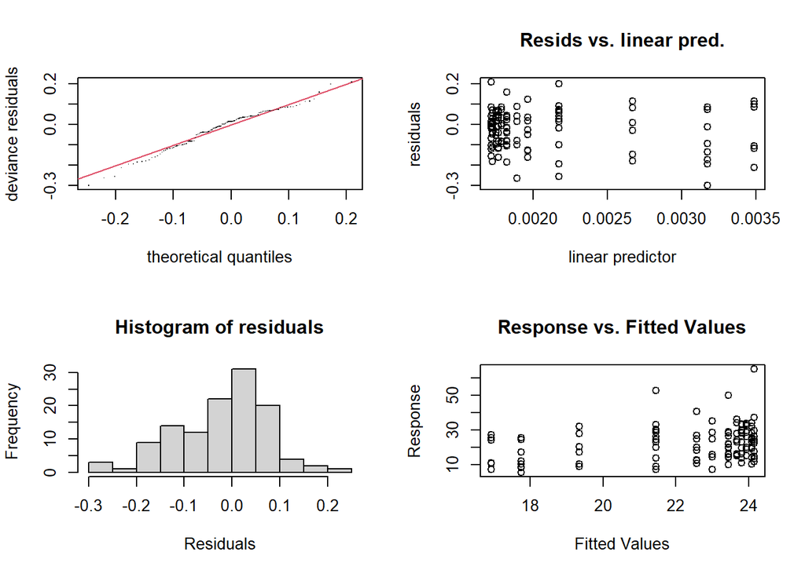

```
##
## Method: GCV   Optimizer: outer newton
## full convergence after 4 iterations.
## Gradient range [-7.194329e-14,-7.194329e-14]
## (score 0.01031498 & scale 0.008253778).
## Hessian positive definite, eigenvalue range [9.707093e-05,9.707093e-05].
## Model rank =  10 / 10
##
## Basis dimension (k) checking results. Low p-value (k-index<1) may
## indicate that k is too low, especially if edf is close to k'.
##
##              k' edf k-index p-value
## s(Latitude) 9.0 1.8    1.12    0.94
```

```r
par(mfrow = c(2, 2))
gam.check(Length_mod3)
```

```r
new_data <- data.frame(Latitude = seq(min(Size_fish$Latitude), max(Size_fish$Latitude), length.out = 100))
predictions <- predict(Length_mod3, newdata = new_data, type = "link", se.fit = TRUE)

# Combine predicted values with new_data
ilink <- family(Length_mod3)$linkinv
pred <- cbind(new_data, predictions)
pred <- transform(pred, lwr_ci = ilink(fit - (2 * se.fit)),
                        upr_ci = ilink(fit + (2 * se.fit)),
                        fitted = ilink(fit))
```

```r
# Plot the GAM model predictions
Size_plot <- ggplot() +
  geom_jitter(data = Size_fish, aes(x= Latitude, y=mean_Size_sp), width = 0.08, height = 0.5, size = 1, alpha = 0.6) +
  geom_ribbon(data = pred, aes(x = Latitude, y = fitted, ymin = lwr_ci, ymax = upr_ci), alpha = 0.2) +
  geom_line(data = pred, aes(x = Latitude, y = fitted), linewidth = 0.6) +
  Theme1 +
labs( y="Fish length (cm)", x="Latitude (°S)") +
theme(axis.title.x=element_blank(),
        axis.text.x=element_blank())
```

#### 13) Phlorotannins vs latitude

```r
Phlorotannins_metadata$Latitude <- Phlorotannins_metadata$Latitude*-1
```

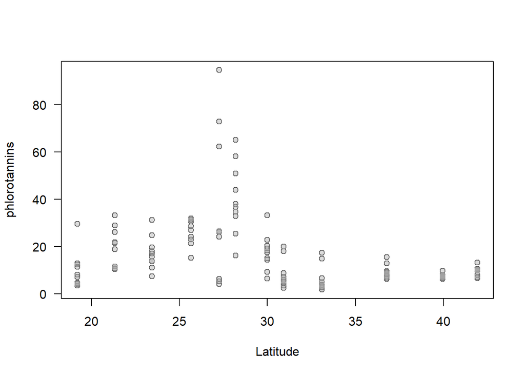

```r
# First, examine a simple scatter plot (always a good idea!)
   plot(Phlorotannins_metadata$Latitude, Phlorotannins_metadata$Phlorotannins, xlab = "Latitude", ylab = "phlorotannins", las=1)
   mygrey <- grey(level = 0.65, alpha = 0.4)
   points(Phlorotannins_metadata$Latitude, Phlorotannins_metadata$Phlorotannins, pch = 21, col = mygrey, bg = mygrey)
```

```r
Phloro_mod1 <- mgcv::gam(Phlorotannins ~ s(Latitude), gamma=1.4, data = Phlorotannins_metadata, family =gaussian())
Phloro_mod2 <- mgcv::gam(Phlorotannins ~ s(Latitude), gamma=1.4, data = Phlorotannins_metadata, family =Gamma())
Phloro_mod3 <- mgcv::gam(Phlorotannins ~ s(Latitude), gamma=1.4,  data = Phlorotannins_metadata, family =inverse.gaussian())
```

```r
AICc(Phloro_mod1, Phloro_mod2, Phloro_mod3)
```

```
##                    df     AICc
## Phloro_mod1  9.380438 934.2137
## Phloro_mod2  8.836817 817.7763
## Phloro_mod3 10.190366 821.3613
```

```r
summary(Phloro_mod2)
```

```
##
## Family: Gamma
## Link function: inverse
##
## Formula:
## Phlorotannins ~ s(Latitude)
##
## Parametric coefficients:
##             Estimate Std. Error t value Pr(>|t|)
## (Intercept) 0.078330   0.003997    19.6   <2e-16 ***
## ---
## Signif. codes:  0 '***' 0.001 '**' 0.01 '*' 0.05 '.' 0.1 ' ' 1
##
## Approximate significance of smooth terms:
##               edf Ref.df     F p-value
## s(Latitude) 6.837  7.933 15.99  <2e-16 ***
## ---
## Signif. codes:  0 '***' 0.001 '**' 0.01 '*' 0.05 '.' 0.1 ' ' 1
##
## R-sq.(adj) =  0.452   Deviance explained = 56.3%
## GCV = 0.32923  Scale est. = 0.2625    n = 120
```

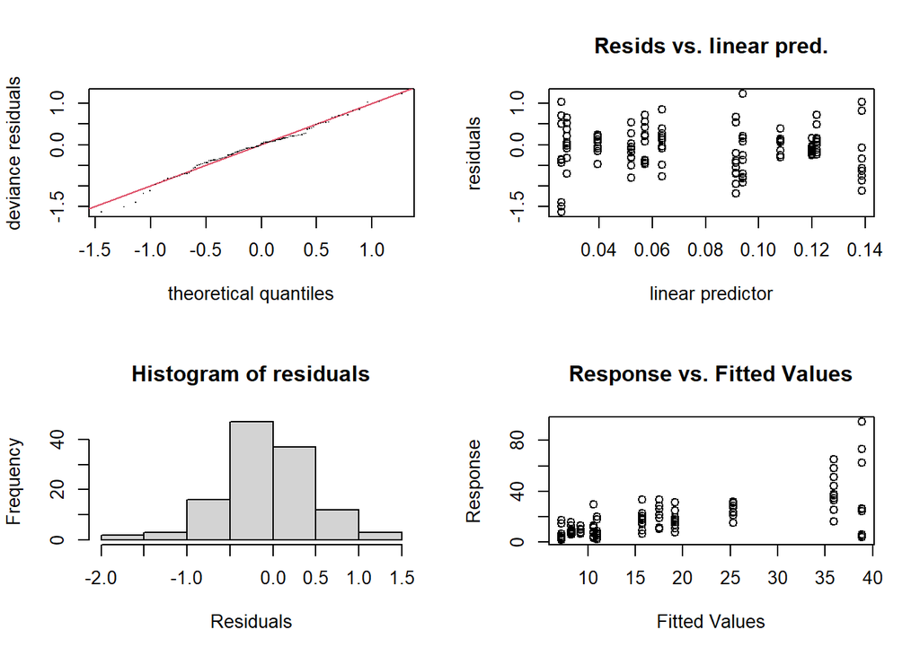

```
##
## Method: GCV   Optimizer: outer newton
## full convergence after 4 iterations.
## Gradient range [3.958715e-07,3.958715e-07]
## (score 0.3292323 & scale 0.2624964).
## Hessian positive definite, eigenvalue range [0.003156813,0.003156813].
## Model rank =  10 / 10
##
## Basis dimension (k) checking results. Low p-value (k-index<1) may
## indicate that k is too low, especially if edf is close to k'.
##
##               k'  edf k-index p-value
## s(Latitude) 9.00 6.84    0.86    0.12
```

```r
par(mfrow = c(2, 2))
gam.check(Phloro_mod2)
```

```r
new_data <- data.frame(Latitude = seq(min(Phlorotannins_metadata$Latitude), max(Phlorotannins_metadata$Latitude), length.out = 100))
predictions <- predict(Phloro_mod2, newdata = new_data, type = "link", se.fit = TRUE)

# Combine predicted values with new_data
ilink <- family(Phloro_mod2)$linkinv
pred <- cbind(new_data, predictions)
pred <- transform(pred, lwr_ci = ilink(fit - (2 * se.fit)),
                        upr_ci = ilink(fit + (2 * se.fit)),
                        fitted = ilink(fit))
```

```r
# Plot the GAM model predictions
Phloro_plot <- ggplot() +
  geom_jitter(data = Phlorotannins_metadata, aes(x= Latitude, y=Phlorotannins), width = 0.08, height = 0.5, size = 1, alpha = 0.6) +
  geom_ribbon(data = pred, aes(x = Latitude, y = fitted, ymin = lwr_ci, ymax = upr_ci), alpha = 0.2) +
  geom_line(data = pred, aes(x = Latitude, y = fitted), linewidth = 0.6) +
  Theme1 +
labs( y="Phlorotannins (mg"~g^-1*" DW)", x="Latitude (°S)")
```

#### Final plots

1. Figure 2 - Abiotic predictors

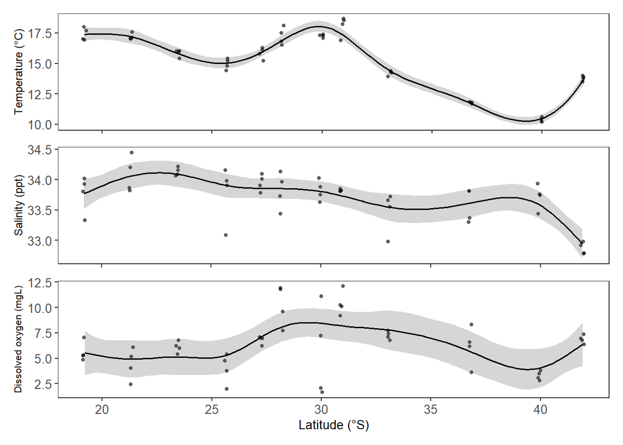

```r
Temperature_plot + Salinity_plot + Oxygen_plot + plot_layout(ncol=1)
```

```r
ggsave("Latitudevsabiotic.jpeg", units="mm", width=75, height=125, dpi=300)
```

2. Figure 3

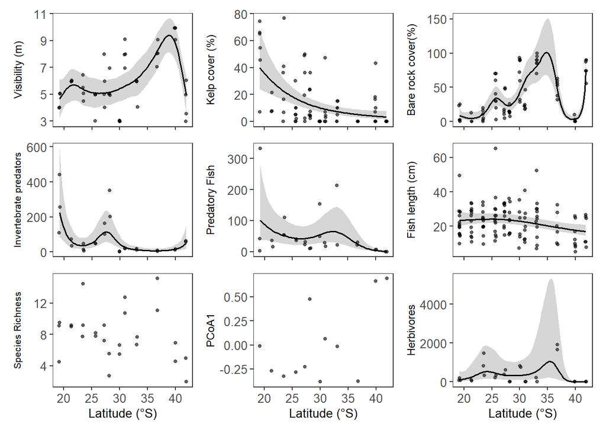

```r
Visibility_plot + Kelp_plot + Bare_plot + Inv_plot + PredFish_plot + Size_plot + Richness_plot + PCOA_plot+ Herb_plot + plot_layout(ncol=3)
```

Figure 3: Latitudinal variation of biotic and habitat variables

```r
ggsave("FigurelatvsBio.jpeg", units="mm", width=150, height=100, dpi=300)
```

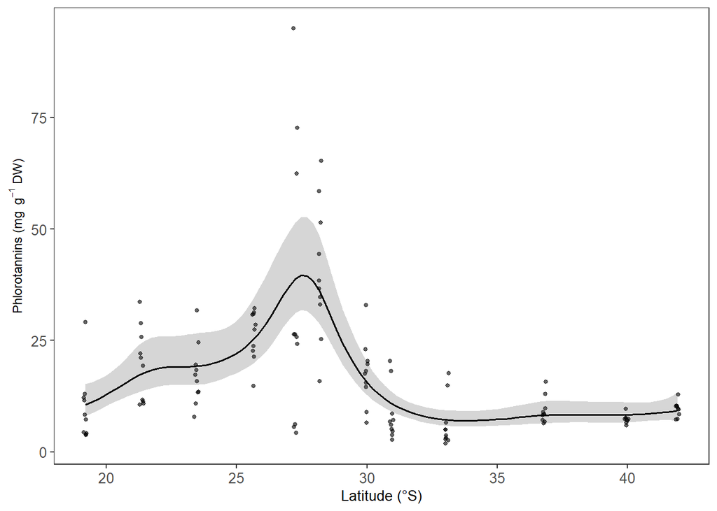

```r
Phloro_plot
```

```r
ggsave("phloro1.jpeg", units="mm", width=90, height=60, dpi=300)
```

## **Part 4:** Latitudinal patterns in consumption

Latitudinal patterns in consumption (predation and herbivory) were explored and analysed

### **4a):** Predation vs latitude

First change latitude to positive numbers for plotting

```r
Predation_env$Latitude <- Predation_env$Latitude*-1
```

```r
C_24 <- filter(Predation_env, Bait2 == "Crabs" & Assay_time2 == 24)
C_2 <- filter(Predation_env, Bait2 == "Crabs" & Assay_time2 == 2)
S_24 <- filter(Predation_env, Bait2 == "Squidpops" & Assay_time2 == 24)
S_2 <- filter(Predation_env, Bait2 == "Squidpops" & Assay_time2 == 2)
```

#### 1) Crabs 2h

*a.* Analyses

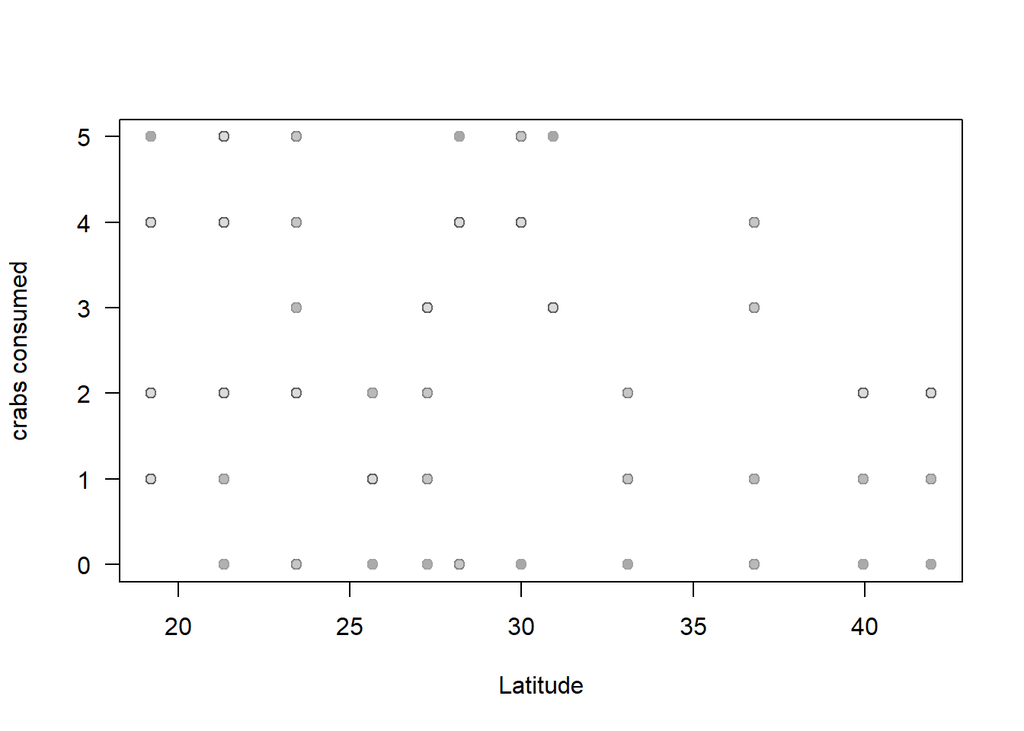

```r
# First, examine a simple scatter plot (always a good idea!)
   plot(C_2$Latitude, C_2$Consumed_individuals, xlab = "Latitude", ylab = "crabs consumed", las=1)
   mygrey <- grey(level = 0.65, alpha = 0.4)
   points(C_2$Latitude, C_2$Consumed_individuals, pch = 21, col = mygrey, bg = mygrey)
```

```r
C2_mod1 <- mgcv::gam(Consumed_individuals ~ s(Latitude, k=11), gamma=1.4, data = C_2, family =poisson())
C2_mod2 <- mgcv::gam(Consumed_individuals ~ s(Latitude, k=11), gamma=1.4, data = C_2, family =nb())
```

```r
AICc(C2_mod2, C2_mod1)
```

```
##                df     AICc
## C2_mod2  5.106187 446.0867
## C2_mod1 10.781434 428.1046
```

```r
summary(C2_mod1)
```

```
##
## Family: poisson
## Link function: log
##
## Formula:
## Consumed_individuals ~ s(Latitude, k = 11)
##
## Parametric coefficients:
##             Estimate Std. Error z value Pr(>|z|)
## (Intercept)   0.3941     0.0873   4.514 6.37e-06 ***
## ---
## Signif. codes:  0 '***' 0.001 '**' 0.01 '*' 0.05 '.' 0.1 ' ' 1
##
## Approximate significance of smooth terms:
##               edf Ref.df Chi.sq p-value
## s(Latitude) 9.781  9.985  82.34  <2e-16 ***
## ---
## Signif. codes:  0 '***' 0.001 '**' 0.01 '*' 0.05 '.' 0.1 ' ' 1
##
## R-sq.(adj) =  0.404   Deviance explained = 36.5%
## UBRE = 0.8541  Scale est. = 1         n = 120
```

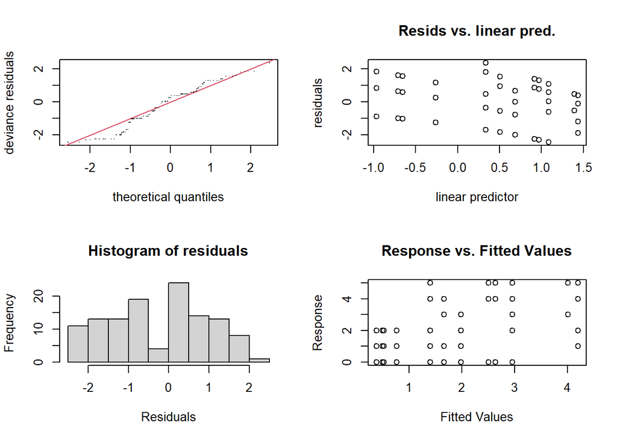

```
##
## Method: UBRE   Optimizer: outer newton
## full convergence after 6 iterations.
## Gradient range [4.749748e-07,4.749748e-07]
## (score 0.8540992 & scale 1).
## Hessian positive definite, eigenvalue range [0.003674509,0.003674509].
## Model rank =  11 / 11
##
## Basis dimension (k) checking results. Low p-value (k-index<1) may
## indicate that k is too low, especially if edf is close to k'.
##
##                k'   edf k-index p-value
## s(Latitude) 10.00  9.78    0.91    0.26
```

```r
par(mfrow = c(2, 2))
gam.check(C2_mod1)
```